# What drives the price of a car?

[figure not shown]

**OVERVIEW**

### CRISP-DM Framework

[figure not shown]

To frame the task, throughout our practical applications we will refer back to a standard process in industry for data projects called CRISP-DM. This process provides a framework for working through a data problem. Your first step in this application will be to read through a brief overview of CRISP-DM [here](https://mo-pcco.s3.us-east-1.amazonaws.com/BH-PCMLAI/module_11/readings_starter.zip). After reading the overview, answer the questions below.

### Business Understanding

From a business perspective, we are tasked with identifying key drivers for used car prices. In the CRISP-DM overview, we are asked to convert this business framing to a data problem definition. Using a few sentences, reframe the task as a data task with the appropriate technical vocabulary.

The mileage of the car may influence the buying decision.

The condition of the car over different owners and driven in different locations might be another factor.

The accident history over the years may influence whether the car is in great, medium, or poor condition.

The color of the car may be a small factor, but still plays a role in the decision buying power.

### Data Understanding

After considering the business understanding, we want to get familiar with our data. Write down some steps that you would take to get to know the dataset and identify any quality issues within. Take time to get to know the dataset and explore what information it contains and how this could be used to inform your business understanding.

The categories involve the various regions: Sedona, Flagstaff, Mohave county, Phoenix, Little Rock, Yuma, Bakersfield, etc.

The catgories involve the car characteristics: The Year, Manufacturer, Cylinders, Model, Type, Size, Fuel are used as major decision categories.

The condition of the car involves:

```
1. Condition: Excellent, Good, like New.
2. Odometer
3. Title: Clean, Rebuilt, Salvage
```

VIN: Shown but might not be used.

### Data Preparation

After our initial exploration and fine tuning of the business understanding, it is time to construct our final dataset prior to modeling. Here, we want to make sure to handle any integrity issues and cleaning, the engineering of new features, any transformations that we believe should happen (scaling, logarithms, normalization, etc.), and general preparation for modeling with `sklearn`.

There are many missing values in the dataset, so these will need to be fixed.

```python
import pandas as pd
import numpy as np
from scipy import stats


import matplotlib.pyplot as plt
import seaborn as sns
plt.rcParams["figure.figsize"] = (15,9)
plt.style.use("fivethirtyeight")

# prepare data
from sklearn.model_selection import train_test_split

# model
from sklearn.dummy import DummyRegressor
from sklearn.linear_model import LinearRegression
from sklearn.metrics import mean_squared_error
from sklearn.linear_model import Lasso
from sklearn import metrics

import warnings
warnings.filterwarnings("ignore")

df = pd.read_csv("data/vehicles.csv")
```

```python
df.info()
```

```
<class 'pandas.core.frame.DataFrame'>
RangeIndex: 426880 entries, 0 to 426879
Data columns (total 18 columns):
 #   Column        Non-Null Count   Dtype
---  ------        --------------   -----
 0   id            426880 non-null  int64
 1   region        426880 non-null  object
 2   price         426880 non-null  int64
 3   year          425675 non-null  float64
 4   manufacturer  409234 non-null  object
 5   model         421603 non-null  object
 6   condition     252776 non-null  object
 7   cylinders     249202 non-null  object
 8   fuel          423867 non-null  object
 9   odometer      422480 non-null  float64
 10  title_status  418638 non-null  object
 11  transmission  424324 non-null  object
 12  VIN           265838 non-null  object
 13  drive         296313 non-null  object
 14  size          120519 non-null  object
 15  type          334022 non-null  object
 16  paint_color   296677 non-null  object
 17  state         426880 non-null  object
dtypes: float64(2), int64(2), object(14)
memory usage: 58.6+ MB
```

```python
df.shape
```

```
(426880, 18)
```

```python
orig_df = df.copy()
```

```python
df.columns
```

```
Index(['id', 'region', 'price', 'year', 'manufacturer', 'model', 'condition',
       'cylinders', 'fuel', 'odometer', 'title_status', 'transmission', 'VIN',
       'drive', 'size', 'type', 'paint_color', 'state'],
      dtype='object')
```

```python
df.head()
```

|  | id | region | price | year | manufacturer | model | condition | cylinders | fuel | odometer | title_status | transmission | VIN | drive | size | type | paint_color | state |
| --- | --- | --- | --- | --- | --- | --- | --- | --- | --- | --- | --- | --- | --- | --- | --- | --- | --- | --- |
| 0 | 7222695916 | prescott | 6000 | NaN | NaN | NaN | NaN | NaN | NaN | NaN | NaN | NaN | NaN | NaN | NaN | NaN | NaN | az |
| 1 | 7218891961 | fayetteville | 11900 | NaN | NaN | NaN | NaN | NaN | NaN | NaN | NaN | NaN | NaN | NaN | NaN | NaN | NaN | ar |
| 2 | 7221797935 | florida keys | 21000 | NaN | NaN | NaN | NaN | NaN | NaN | NaN | NaN | NaN | NaN | NaN | NaN | NaN | NaN | fl |
| 3 | 7222270760 | worcester / central MA | 1500 | NaN | NaN | NaN | NaN | NaN | NaN | NaN | NaN | NaN | NaN | NaN | NaN | NaN | NaN | ma |
| 4 | 7210384030 | greensboro | 4900 | NaN | NaN | NaN | NaN | NaN | NaN | NaN | NaN | NaN | NaN | NaN | NaN | NaN | NaN | nc |

```python
df.nunique(axis=0)
```

```
id              426880
region             404
price            15655
year               114
manufacturer        42
model            29649
condition            6
cylinders            8
fuel                 5
odometer        104870
title_status         6
transmission         3
VIN             118246
drive                3
size                 4
type                13
paint_color         12
state               51
dtype: int64
```

```python
df.describe().apply(lambda s: s.apply(lambda x: format(x, '.2f')))
```

|  | id | price | year | odometer |
| --- | --- | --- | --- | --- |
| count | 426880.00 | 426880.00 | 425675.00 | 422480.00 |
| mean | 7311486634.22 | 75199.03 | 2011.24 | 98043.33 |
| std | 4473170.41 | 12182282.17 | 9.45 | 213881.50 |
| min | 7207408119.00 | 0.00 | 1900.00 | 0.00 |
| 25% | 7308143339.25 | 5900.00 | 2008.00 | 37704.00 |
| 50% | 7312620821.00 | 13950.00 | 2013.00 | 85548.00 |
| 75% | 7315253543.50 | 26485.75 | 2017.00 | 133542.50 |
| max | 7317101084.00 | 3736928711.00 | 2022.00 | 10000000.00 |

```python
#NA_val = df.isna().sum()

df.columns = df.columns.str.lower()
df.columns = df.columns.str.strip()
df.columns = df.columns.str.replace(" ", "_")
```

```python
df.columns.str.lower()
df.columns.str.replace(" ", "_")
df.columns.str.strip()
```

```
Index(['id', 'region', 'price', 'year', 'manufacturer', 'model', 'condition',
       'cylinders', 'fuel', 'odometer', 'title_status', 'transmission', 'vin',
       'drive', 'size', 'type', 'paint_color', 'state'],
      dtype='object')
```

```python
df.columns
```

```
Index(['id', 'region', 'price', 'year', 'manufacturer', 'model', 'condition',
       'cylinders', 'fuel', 'odometer', 'title_status', 'transmission', 'vin',
       'drive', 'size', 'type', 'paint_color', 'state'],
      dtype='object')
```

```python
# Source: https://towardsdatascience.com/a-machine-learning-project-predicting-used-car-prices-efbc4d2a4998

#def na_filter(na, threshold = .4):

#only select variables that passes the threshold
#    col_pass = []
#    for i in na.keys():
#        if na[i]/df.shape[0]<threshold:
#            col_pass.append(i)
#    return col_pass
#df_cleaned = df[na_filter(NA_val)]
#df_cleaned.columns
```

**Duplicate Check**

```python
sum(df.duplicated())
```

```
0
```

```python
df[~df.duplicated()]
```

|  | id | region | price | year | manufacturer | model | condition | cylinders | fuel | odometer | title_status | transmission | vin | drive | size | type | paint_color | state |
| --- | --- | --- | --- | --- | --- | --- | --- | --- | --- | --- | --- | --- | --- | --- | --- | --- | --- | --- |
| 0 | 7222695916 | prescott | 6000 | NaN | NaN | NaN | NaN | NaN | NaN | NaN | NaN | NaN | NaN | NaN | NaN | NaN | NaN | az |
| 1 | 7218891961 | fayetteville | 11900 | NaN | NaN | NaN | NaN | NaN | NaN | NaN | NaN | NaN | NaN | NaN | NaN | NaN | NaN | ar |
| 2 | 7221797935 | florida keys | 21000 | NaN | NaN | NaN | NaN | NaN | NaN | NaN | NaN | NaN | NaN | NaN | NaN | NaN | NaN | fl |
| 3 | 7222270760 | worcester / central MA | 1500 | NaN | NaN | NaN | NaN | NaN | NaN | NaN | NaN | NaN | NaN | NaN | NaN | NaN | NaN | ma |
| 4 | 7210384030 | greensboro | 4900 | NaN | NaN | NaN | NaN | NaN | NaN | NaN | NaN | NaN | NaN | NaN | NaN | NaN | NaN | nc |
| ... | ... | ... | ... | ... | ... | ... | ... | ... | ... | ... | ... | ... | ... | ... | ... | ... | ... | ... |
| 426875 | 7301591192 | wyoming | 23590 | 2019.0 | nissan | maxima s sedan 4d | good | 6 cylinders | gas | 32226.0 | clean | other | 1N4AA6AV6KC367801 | fwd | NaN | sedan | NaN | wy |
| 426876 | 7301591187 | wyoming | 30590 | 2020.0 | volvo | s60 t5 momentum sedan 4d | good | NaN | gas | 12029.0 | clean | other | 7JR102FKXLG042696 | fwd | NaN | sedan | red | wy |
| 426877 | 7301591147 | wyoming | 34990 | 2020.0 | cadillac | xt4 sport suv 4d | good | NaN | diesel | 4174.0 | clean | other | 1GYFZFR46LF088296 | NaN | NaN | hatchback | white | wy |
| 426878 | 7301591140 | wyoming | 28990 | 2018.0 | lexus | es 350 sedan 4d | good | 6 cylinders | gas | 30112.0 | clean | other | 58ABK1GG4JU103853 | fwd | NaN | sedan | silver | wy |
| 426879 | 7301591129 | wyoming | 30590 | 2019.0 | bmw | 4 series 430i gran coupe | good | NaN | gas | 22716.0 | clean | other | WBA4J1C58KBM14708 | rwd | NaN | coupe | NaN | wy |

426880 rows × 18 columns

```python
df.shape
```

```
(426880, 18)
```

**Missing Value Check**

```python
df.isna().sum()
```

```
id                   0
region               0
price                0
year              1205
manufacturer     17646
model             5277
condition       174104
cylinders       177678
fuel              3013
odometer          4400
title_status      8242
transmission      2556
vin             161042
drive           130567
size            306361
type             92858
paint_color     130203
state                0
dtype: int64
```

```python
# Another way to get precentages
df.isna().mean().round(5)*100
```

```
id               0.000
region           0.000
price            0.000
year             0.282
manufacturer     4.134
model            1.236
condition       40.785
cylinders       41.622
fuel             0.706
odometer         1.031
title_status     1.931
transmission     0.599
vin             37.725
drive           30.586
size            71.767
type            21.753
paint_color     30.501
state            0.000
dtype: float64
```

```python
# Number of Rows
df.shape[0]
```

```
426880
```

```python
pd.set_option('display.float_format', lambda x: '%.2f' % x)
```

```python
df[['price']].describe()
```

|  | price |
| --- | --- |
| count | 426880.00 |
| mean | 75199.03 |
| std | 12182282.17 |
| min | 0.00 |
| 25% | 5900.00 |
| 50% | 13950.00 |
| 75% | 26485.75 |
| max | 3736928711.00 |

```python
p = [0.05, .85,.95, .99]
```

```python
df[['price']].describe(p)
```

|  | price |
| --- | --- |
| count | 426880.00 |
| mean | 75199.03 |
| std | 12182282.17 |
| min | 0.00 |
| 5% | 0.00 |
| 50% | 13950.00 |
| 85% | 32995.00 |
| 95% | 44500.00 |
| 99% | 66995.00 |
| max | 3736928711.00 |

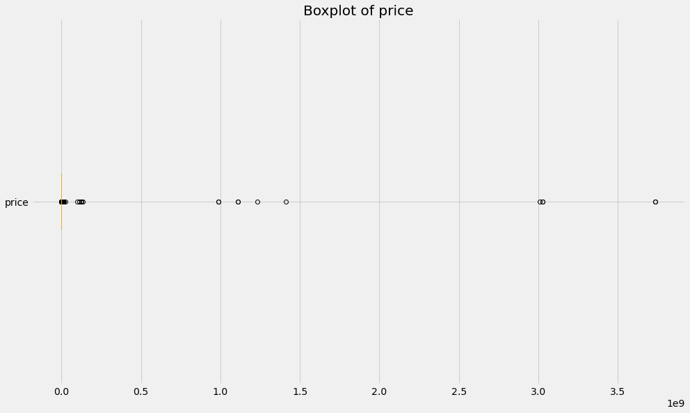

```python
df['price'].plot(kind = 'box', vert = False, title = "Boxplot of price");
```

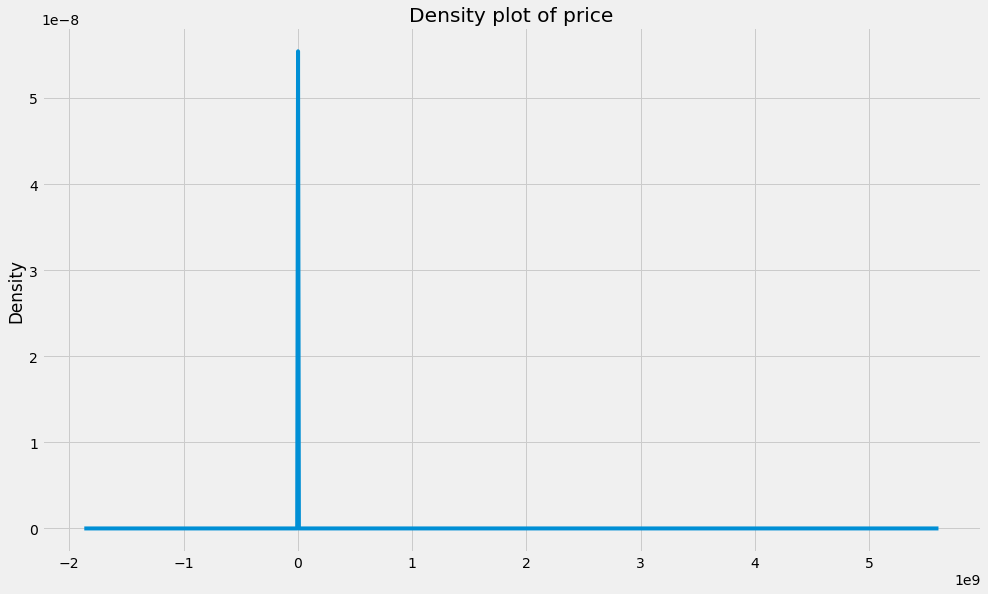

```python
df['price'].plot(kind = 'density', title = "Density plot of price");
```

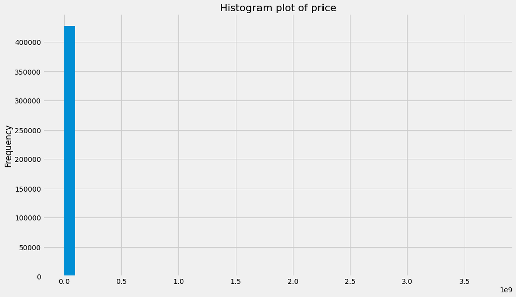

```python
df['price'].plot(kind = 'hist', bins = 40, title = "Histogram plot of price");
```

```python
df["price_log"] = np.log(df['price'])
```

```python
df.head(3)
```

|  | id | region | price | year | manufacturer | model | condition | cylinders | fuel | odometer | title_status | transmission | vin | drive | size | type | paint_color | state | price_log |
| --- | --- | --- | --- | --- | --- | --- | --- | --- | --- | --- | --- | --- | --- | --- | --- | --- | --- | --- | --- |
| 0 | 7222695916 | prescott | 6000 | NaN | NaN | NaN | NaN | NaN | NaN | NaN | NaN | NaN | NaN | NaN | NaN | NaN | NaN | az | 8.70 |
| 1 | 7218891961 | fayetteville | 11900 | NaN | NaN | NaN | NaN | NaN | NaN | NaN | NaN | NaN | NaN | NaN | NaN | NaN | NaN | ar | 9.38 |
| 2 | 7221797935 | florida keys | 21000 | NaN | NaN | NaN | NaN | NaN | NaN | NaN | NaN | NaN | NaN | NaN | NaN | NaN | NaN | fl | 9.95 |

## Data Pre-processing

```python
df.tail()
```

|  | id | region | price | year | manufacturer | model | condition | cylinders | fuel | odometer | title_status | transmission | vin | drive | size | type | paint_color | state | price_log |
| --- | --- | --- | --- | --- | --- | --- | --- | --- | --- | --- | --- | --- | --- | --- | --- | --- | --- | --- | --- |
| 426875 | 7301591192 | wyoming | 23590 | 2019.00 | nissan | maxima s sedan 4d | good | 6 cylinders | gas | 32226.00 | clean | other | 1N4AA6AV6KC367801 | fwd | NaN | sedan | NaN | wy | 10.07 |
| 426876 | 7301591187 | wyoming | 30590 | 2020.00 | volvo | s60 t5 momentum sedan 4d | good | NaN | gas | 12029.00 | clean | other | 7JR102FKXLG042696 | fwd | NaN | sedan | red | wy | 10.33 |
| 426877 | 7301591147 | wyoming | 34990 | 2020.00 | cadillac | xt4 sport suv 4d | good | NaN | diesel | 4174.00 | clean | other | 1GYFZFR46LF088296 | NaN | NaN | hatchback | white | wy | 10.46 |
| 426878 | 7301591140 | wyoming | 28990 | 2018.00 | lexus | es 350 sedan 4d | good | 6 cylinders | gas | 30112.00 | clean | other | 58ABK1GG4JU103853 | fwd | NaN | sedan | silver | wy | 10.27 |
| 426879 | 7301591129 | wyoming | 30590 | 2019.00 | bmw | 4 series 430i gran coupe | good | NaN | gas | 22716.00 | clean | other | WBA4J1C58KBM14708 | rwd | NaN | coupe | NaN | wy | 10.33 |

```python
# Before we build a model, we will do pre-processing
# Keep it simple and create a list
numeric_cols = ['price', 'year', 'cylinders', 'odometer']
df[numeric_cols]
```

|  | price | year | cylinders | odometer |
| --- | --- | --- | --- | --- |
| 0 | 6000 | NaN | NaN | NaN |
| 1 | 11900 | NaN | NaN | NaN |
| 2 | 21000 | NaN | NaN | NaN |
| 3 | 1500 | NaN | NaN | NaN |
| 4 | 4900 | NaN | NaN | NaN |
| ... | ... | ... | ... | ... |
| 426875 | 23590 | 2019.00 | 6 cylinders | 32226.00 |
| 426876 | 30590 | 2020.00 | NaN | 12029.00 |
| 426877 | 34990 | 2020.00 | NaN | 4174.00 |
| 426878 | 28990 | 2018.00 | 6 cylinders | 30112.00 |
| 426879 | 30590 | 2019.00 | NaN | 22716.00 |

426880 rows × 4 columns

```python
df_numeric = df[numeric_cols].copy()
```

```python
df_numeric.dtypes
```

```
price          int64
year         float64
cylinders     object
odometer     float64
dtype: object
```

```python
df_numeric.astype
```

```
<bound method NDFrame.astype of         price    year    cylinders  odometer
0        6000     NaN          NaN       NaN
1       11900     NaN          NaN       NaN
2       21000     NaN          NaN       NaN
3        1500     NaN          NaN       NaN
4        4900     NaN          NaN       NaN
...       ...     ...          ...       ...
426875  23590 2019.00  6 cylinders  32226.00
426876  30590 2020.00          NaN  12029.00
426877  34990 2020.00          NaN   4174.00
426878  28990 2018.00  6 cylinders  30112.00
426879  30590 2019.00          NaN  22716.00

[426880 rows x 4 columns]>
```

```python
# Change the "Cylinders 6" to numeric 6, etc.
def set_number(row):
    if row["cylinders"] == '6 cylinders':
        return "6"
    elif row["cylinders"] == '4 cylinders':
        return "4"
    elif row["cylinders"] == '3 cylinders':
        return "3"
    elif row["cylinders"] == '5 cylinders':
        return "5"
    elif row["cylinders"] == '8 cylinders':
        return "8"
    elif row["cylinders"] == '10 cylinders':
        return "10"
    elif row["cylinders"] == '12 cylinders':
        return "12"
    elif row["cylinders"] == '10 cylinders':
        return "10"
    elif row["cylinders"] == 'other':
        return "0"
    else:
        return "0"

df_numeric = df_numeric.assign(cylinders = df_numeric.apply(set_number, axis=1))
```

```python
df_numeric.tail()
```

|  | price | year | cylinders | odometer |
| --- | --- | --- | --- | --- |
| 426875 | 23590 | 2019.00 | 6 | 32226.00 |
| 426876 | 30590 | 2020.00 | 0 | 12029.00 |
| 426877 | 34990 | 2020.00 | 0 | 4174.00 |
| 426878 | 28990 | 2018.00 | 6 | 30112.00 |
| 426879 | 30590 | 2019.00 | 0 | 22716.00 |

```python
df_numeric.isna().sum()
```

```
price           0
year         1205
cylinders       0
odometer     4400
dtype: int64
```

```python
# Another way to get precentages
df_numeric.isna().mean().round(5)*100
```

```
price       0.00
year        0.28
cylinders   0.00
odometer    1.03
dtype: float64
```

```python
df_numeric["price_log"] = np.log(df_numeric['price'])
df_numeric["price_log"]
```

```
0         8.70
1         9.38
2         9.95
3         7.31
4         8.50
          ...
426875   10.07
426876   10.33
426877   10.46
426878   10.27
426879   10.33
Name: price_log, Length: 426880, dtype: float64
```

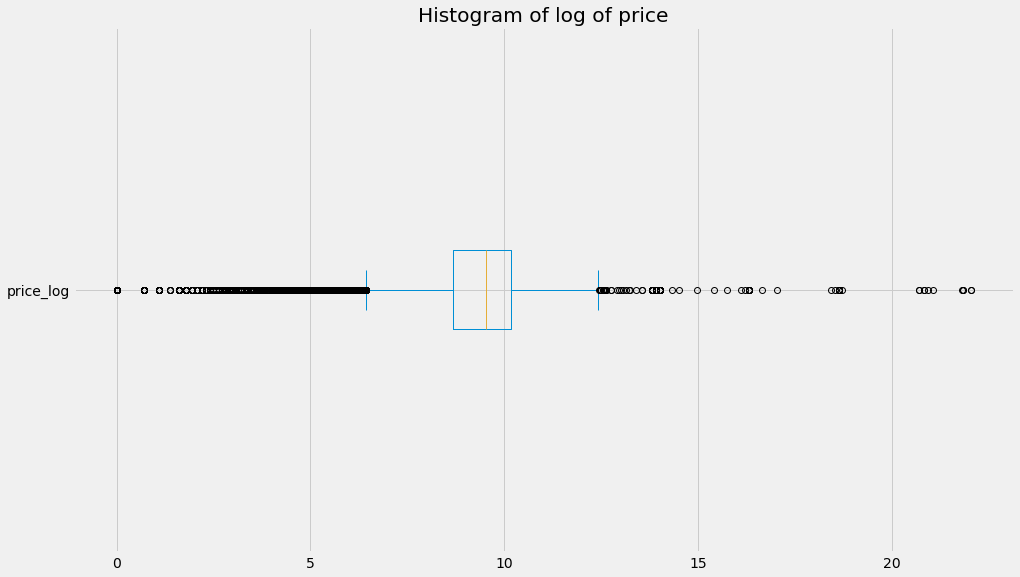

```python
df_numeric['price_log'].plot(kind = 'box', title = "Histogram of log of price", vert = False);
```

```python
df_numeric.max()
```

```
price        3736928711
year            2022.00
cylinders             8
odometer    10000000.00
price_log         22.04
dtype: object
```

```python
df_numeric.isnull().sum()
```

```
price           0
year         1205
cylinders       0
odometer     4400
price_log       0
dtype: int64
```

```python
# Replace infinite updated data with nan
df_numeric.replace([np.inf, -np.inf], np.nan, inplace=True)
```

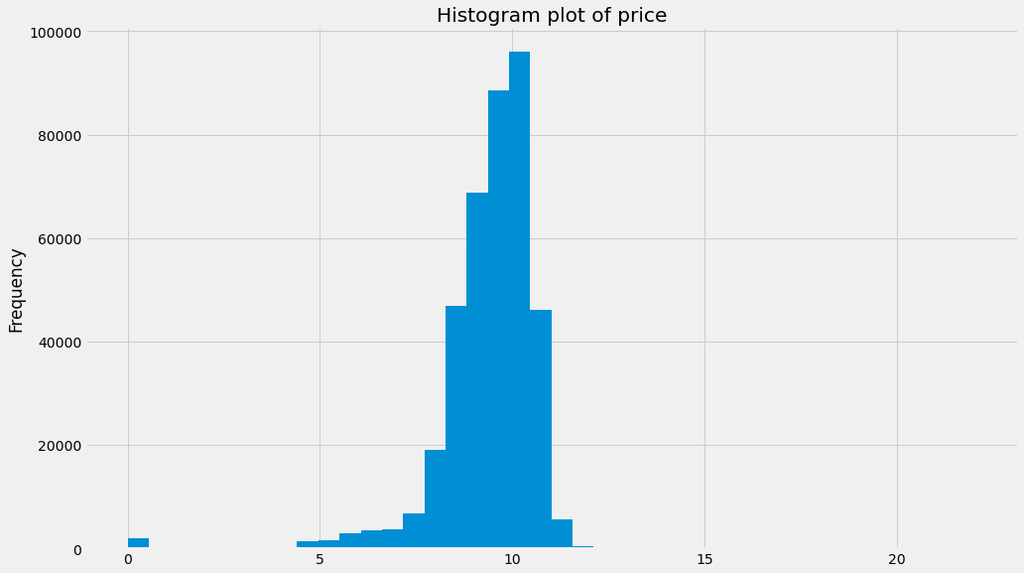

```python
df_numeric['price_log'].plot(kind = 'hist', bins = 40, title = "Histogram plot of price");
```

```python
# Fill all the missing values with median values
#df_numeric.fillna(df.median(), inplace = True)
#df=_numeric = df_numeric['price'].fillna(df['price'].median(), inplace=True)

#df_numeric = df_numeric.dropna((df_numeric['year'] == 'NaN') & (df_numeric['cylinders'] == 0) & (df_numeric['odometer'] == 'NaN'), inplace=True)
```

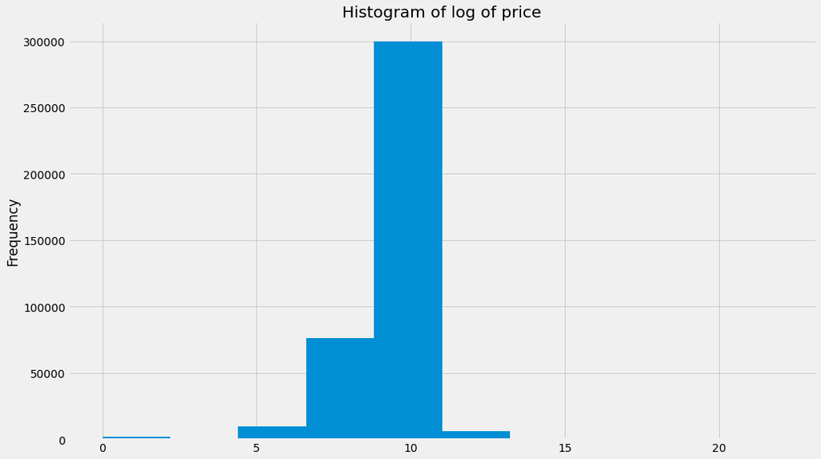

```python
df_numeric['price_log'].plot(kind = 'hist', title = "Histogram of log of price");
```

```python
# Fill all teh missing values with median values
df_numeric.fillna(df_numeric.median(), inplace = True)
```

## Outlier Treatment

```python
# Z SCORE to throw out outliers
df_zscore = df_numeric[np.abs(stats.zscore(df_numeric['price'])) < 3].copy()
```

```python
df_zscore.shape
```

```
(426860, 5)
```

```python
df = pd.read_csv("data/vehicles.csv")
df.isna().sum()
```

```
id                   0
region               0
price                0
year              1205
manufacturer     17646
model             5277
condition       174104
cylinders       177678
fuel              3013
odometer          4400
title_status      8242
transmission      2556
VIN             161042
drive           130567
size            306361
type             92858
paint_color     130203
state                0
dtype: int64
```

```python
# Replace infinite updated data with nan
df_numeric.replace([np.inf, -np.inf], np.nan, inplace=True)
```

```python
iqr_data_lost = 1-(df_zscore.shape[0]/df.shape[0])
print("We lost {:.2%} of the data by the z-score method".format(iqr_data_lost))
```

```
We lost 0.00% of the data by the z-score method
```

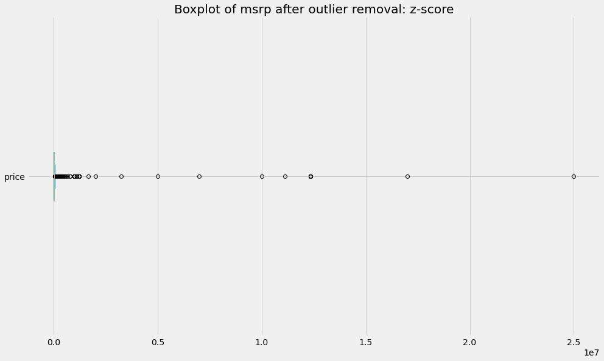

```python
df_zscore['price'].plot(kind = 'box', vert = False, title = "Boxplot of msrp after outlier removal: z-score");
```

### IQR Treatement

```python
iqr = df['price'].quantile(.75) - df['price'].quantile(.25)
iqr
```

```
20585.75
```

```python
lower_bound = df['price'].quantile(.25) - 1.5 * iqr
upper_bound = df['price'].quantile(.75) + 1.5 * iqr
```

```python
df_iqr = df[(df['price'] > lower_bound) & (df['price'] < upper_bound)].copy()
```

```python
iqr_data_lost = 1-(df_iqr.shape[0]/df.shape[0])
print("We lost {:.2%} of the data by the IQR method".format(iqr_data_lost))
```

```
We lost 1.92% of the data by the IQR method
```

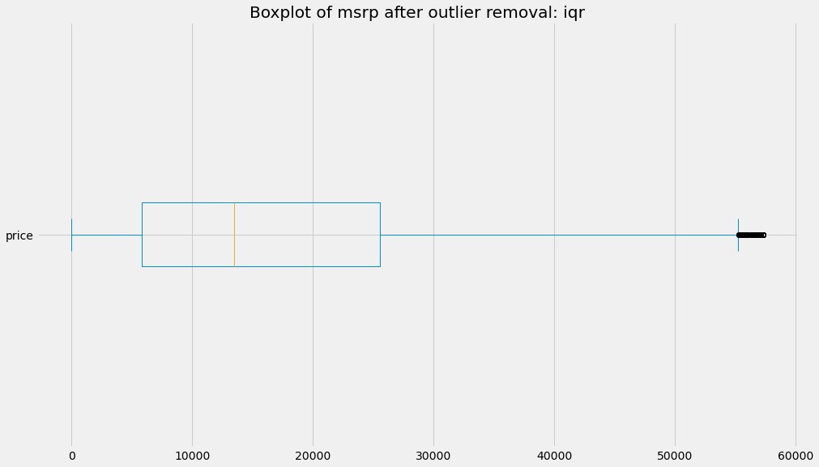

```python
df_iqr['price'].plot(kind = 'box', vert = False, title = "Boxplot of msrp after outlier removal: iqr");
```

## Bivariate Analysis

```python
df = pd.read_csv("data/vehicles.csv")
df.head()
```

|  | id | region | price | year | manufacturer | model | condition | cylinders | fuel | odometer | title_status | transmission | VIN | drive | size | type | paint_color | state |
| --- | --- | --- | --- | --- | --- | --- | --- | --- | --- | --- | --- | --- | --- | --- | --- | --- | --- | --- |
| 0 | 7222695916 | prescott | 6000 | NaN | NaN | NaN | NaN | NaN | NaN | NaN | NaN | NaN | NaN | NaN | NaN | NaN | NaN | az |
| 1 | 7218891961 | fayetteville | 11900 | NaN | NaN | NaN | NaN | NaN | NaN | NaN | NaN | NaN | NaN | NaN | NaN | NaN | NaN | ar |
| 2 | 7221797935 | florida keys | 21000 | NaN | NaN | NaN | NaN | NaN | NaN | NaN | NaN | NaN | NaN | NaN | NaN | NaN | NaN | fl |
| 3 | 7222270760 | worcester / central MA | 1500 | NaN | NaN | NaN | NaN | NaN | NaN | NaN | NaN | NaN | NaN | NaN | NaN | NaN | NaN | ma |
| 4 | 7210384030 | greensboro | 4900 | NaN | NaN | NaN | NaN | NaN | NaN | NaN | NaN | NaN | NaN | NaN | NaN | NaN | NaN | nc |

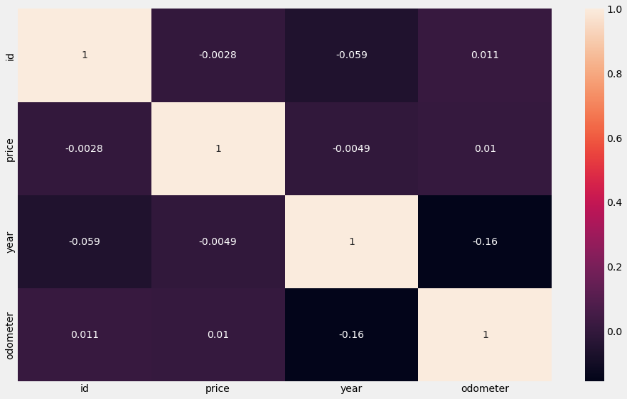

```python
corr = df.corr()
sns.heatmap(corr, annot = True);
```

**Creating a triangular heatmap**

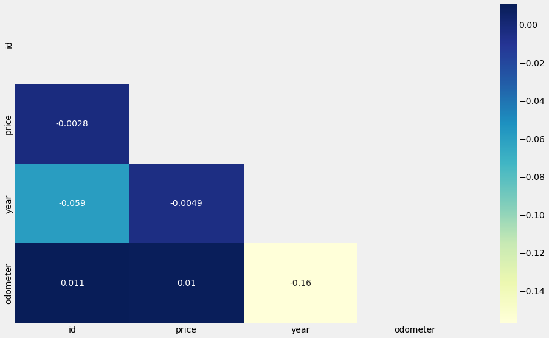

```python
mask = np.triu(np.ones_like(df.corr().round(2)))
sns.heatmap(corr, annot=True, mask=mask, cmap="YlGnBu");
```

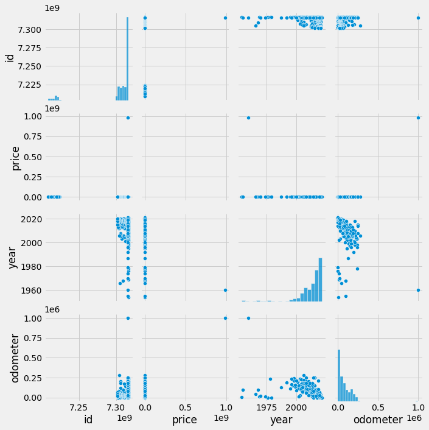

```python
sns.pairplot(df[0:300]);
```

### Categorical Value relationship

```python
df['region'].unique()
```

```
array(['prescott', 'fayetteville', 'florida keys',
       'worcester / central MA', 'greensboro', 'hudson valley',
       'medford-ashland', 'erie', 'el paso', 'bellingham',
       'skagit / island / SJI', 'la crosse', 'auburn', 'birmingham',
       'dothan', 'florence / muscle shoals', 'gadsden-anniston',
       'huntsville / decatur', 'mobile', 'montgomery', 'tuscaloosa',
       'anchorage / mat-su', 'fairbanks', 'kenai peninsula',
       'southeast alaska', 'flagstaff / sedona', 'mohave county',
       'phoenix', 'show low', 'sierra vista', 'tucson', 'yuma',
       'fort smith', 'jonesboro', 'little rock', 'texarkana',
       'bakersfield', 'chico', 'fresno / madera', 'gold country',
       'hanford-corcoran', 'humboldt county', 'imperial county',
       'inland empire', 'los angeles', 'mendocino county', 'merced',
       'modesto', 'monterey bay', 'orange county', 'palm springs',
       'redding', 'reno / tahoe', 'sacramento', 'san diego',
       'san luis obispo', 'santa barbara', 'santa maria', 'SF bay area',
       'siskiyou county', 'stockton', 'susanville', 'ventura county',
       'visalia-tulare', 'yuba-sutter', 'boulder', 'colorado springs',
       'denver', 'eastern CO', 'fort collins / north CO', 'high rockies',
       'pueblo', 'western slope', 'eastern CT', 'hartford', 'new haven',
       'northwest CT', 'washington, DC', 'delaware', 'daytona beach',
       'ft myers / SW florida', 'gainesville', 'heartland florida',
       'jacksonville', 'lakeland', 'north central FL', 'ocala',
       'okaloosa / walton', 'orlando', 'panama city', 'pensacola',
       'sarasota-bradenton', 'south florida', 'space coast',
       'st augustine', 'tallahassee', 'tampa bay area', 'treasure coast',
       'albany', 'athens', 'atlanta', 'augusta', 'brunswick', 'columbus',
       'macon / warner robins', 'northwest GA', 'savannah / hinesville',
       'statesboro', 'valdosta', 'hawaii', 'boise', 'east idaho',
       'lewiston / clarkston', 'pullman / moscow',
       "spokane / coeur d'alene", 'twin falls', 'bloomington-normal',
       'champaign urbana', 'chicago', 'decatur', 'la salle co',
       'mattoon-charleston', 'peoria', 'quad cities, IA/IL', 'rockford',
       'southern illinois', 'springfield', 'st louis, MO', 'western IL',
       'bloomington', 'evansville', 'fort wayne', 'indianapolis',
       'kokomo', 'lafayette / west lafayette', 'muncie / anderson',
       'richmond', 'south bend / michiana', 'terre haute', 'ames',
       'cedar rapids', 'des moines', 'dubuque', 'fort dodge', 'iowa city',
       'mason city', 'omaha / council bluffs', 'sioux city',
       'southeast IA', 'waterloo / cedar falls', 'kansas city, MO',
```

[output cut: 52 more lines]

```
       'del rio / eagle pass', 'galveston', 'houston',
       'killeen / temple / ft hood', 'laredo', 'lubbock',
       'mcallen / edinburg', 'odessa / midland', 'san angelo',
       'san antonio', 'san marcos', 'southwest TX', 'tyler / east TX',
       'victoria', 'waco', 'wichita falls', 'logan', 'ogden-clearfield',
       'provo / orem', 'salt lake city', 'st george', 'vermont',
       'charlottesville', 'danville', 'fredericksburg', 'harrisonburg',
       'lynchburg', 'new river valley', 'norfolk / hampton roads',
       'roanoke', 'southwest VA', 'winchester',
       'kennewick-pasco-richland', 'moses lake', 'olympic peninsula',
       'seattle-tacoma', 'wenatchee', 'yakima', 'eastern panhandle',
       'morgantown', 'southern WV', 'west virginia (old)',
       'appleton-oshkosh-FDL', 'eau claire', 'green bay', 'janesville',
       'kenosha-racine', 'madison', 'milwaukee', 'northern WI',
       'sheboygan', 'wausau', 'wyoming'], dtype=object)
```

```python
df.groupby('region')['price'].describe()
```

| region | count | mean | std | min | 25% | 50% | 75% | max |
| --- | --- | --- | --- | --- | --- | --- | --- | --- |
| SF bay area | 2936.00 | 17038.89 | 15695.68 | 0.00 | 5473.50 | 14965.50 | 24990.00 | 159991.00 |
| abilene | 235.00 | 42234.09 | 137140.24 | 0.00 | 12000.00 | 25750.00 | 37998.00 | 1234567.00 |
| akron / canton | 2211.00 | 92296.11 | 2676628.48 | 0.00 | 5499.00 | 9974.00 | 19890.00 | 123456789.00 |
| albany | 2537.00 | 20489.46 | 16111.28 | 0.00 | 7495.00 | 16995.00 | 29990.00 | 130000.00 |
| albuquerque | 2952.00 | 18260.02 | 17612.35 | 0.00 | 4900.00 | 15000.00 | 27522.50 | 163540.00 |
| ... | ... | ... | ... | ... | ... | ... | ... | ... |
| york | 777.00 | 15981.76 | 14325.08 | 0.00 | 4995.00 | 9500.00 | 28590.00 | 71990.00 |
| youngstown | 664.00 | 52291.02 | 676324.33 | 0.00 | 5995.00 | 9997.00 | 23522.50 | 12345678.00 |
| yuba-sutter | 1747.00 | 14987.23 | 11194.02 | 0.00 | 7988.00 | 10999.00 | 19990.00 | 79999.00 |
| yuma | 335.00 | 30356.59 | 24064.29 | 0.00 | 7650.00 | 24995.00 | 50495.00 | 82995.00 |
| zanesville / cambridge | 313.00 | 19432.62 | 13111.96 | 0.00 | 9795.00 | 15997.00 | 29990.00 | 59000.00 |

404 rows × 8 columns

```python
df['manufacturer'].unique()
```

```
array([nan, 'gmc', 'chevrolet', 'toyota', 'ford', 'jeep', 'nissan', 'ram',
       'mazda', 'cadillac', 'honda', 'dodge', 'lexus', 'jaguar', 'buick',
       'chrysler', 'volvo', 'audi', 'infiniti', 'lincoln', 'alfa-romeo',
       'subaru', 'acura', 'hyundai', 'mercedes-benz', 'bmw', 'mitsubishi',
       'volkswagen', 'porsche', 'kia', 'rover', 'ferrari', 'mini',
       'pontiac', 'fiat', 'tesla', 'saturn', 'mercury', 'harley-davidson',
       'datsun', 'aston-martin', 'land rover', 'morgan'], dtype=object)
```

```python
df.groupby('manufacturer')['price'].describe()
```

| manufacturer | count | mean | std | min | 25% | 50% | 75% | max |
| --- | --- | --- | --- | --- | --- | --- | --- | --- |
| acura | 5978.00 | 19842.87 | 13514.44 | 0.00 | 8499.00 | 18399.50 | 29993.75 | 139999.00 |
| alfa-romeo | 897.00 | 28237.35 | 8042.40 | 0.00 | 27983.00 | 29590.00 | 30990.00 | 62950.00 |
| aston-martin | 24.00 | 53494.54 | 48110.93 | 0.00 | 1947.00 | 46997.50 | 74991.00 | 179888.00 |
| audi | 7573.00 | 23574.85 | 16160.50 | 0.00 | 11599.00 | 23551.00 | 32995.00 | 160000.00 |
| bmw | 14699.00 | 26740.26 | 935753.14 | 0.00 | 8675.00 | 16495.00 | 27950.00 | 113456789.00 |
| buick | 5501.00 | 36784.95 | 1664388.05 | 0.00 | 4890.00 | 11399.00 | 22389.00 | 123456789.00 |
| cadillac | 6953.00 | 19439.52 | 15868.40 | 0.00 | 6950.00 | 15995.00 | 30900.00 | 195000.00 |
| chevrolet | 55064.00 | 115676.10 | 14159570.34 | 0.00 | 5995.00 | 14389.00 | 27995.00 | 3009548743.00 |
| chrysler | 6031.00 | 10442.95 | 14658.89 | 0.00 | 3950.00 | 7499.00 | 14467.50 | 655000.00 |
| datsun | 63.00 | 15149.67 | 9668.37 | 1.00 | 6000.00 | 17900.00 | 22950.00 | 30000.00 |
| dodge | 13707.00 | 15003.20 | 62096.93 | 0.00 | 3950.00 | 9859.00 | 22499.00 | 6995495.00 |
| ferrari | 95.00 | 107438.74 | 86889.87 | 0.00 | 62019.00 | 98900.00 | 137441.50 | 449500.00 |
| fiat | 792.00 | 11890.52 | 7314.55 | 0.00 | 5999.00 | 9995.00 | 19990.00 | 32500.00 |
| ford | 70985.00 | 36411.72 | 4187344.92 | 0.00 | 6395.00 | 14999.00 | 29000.00 | 1111111111.00 |
| gmc | 16785.00 | 30405.88 | 952939.70 | 0.00 | 8499.00 | 20977.00 | 33950.00 | 123456789.00 |
| harley-davidson | 153.00 | 12129.79 | 7668.76 | 0.00 | 6995.00 | 11495.00 | 17995.00 | 39900.00 |
| honda | 21269.00 | 10751.36 | 8735.02 | 0.00 | 4500.00 | 8495.00 | 15498.00 | 123456.00 |
| hyundai | 10338.00 | 10719.66 | 7719.28 | 0.00 | 4950.00 | 9700.00 | 15997.00 | 50000.00 |
| infiniti | 4802.00 | 19561.85 | 12048.43 | 0.00 | 8999.00 | 19995.00 | 28590.00 | 69995.00 |
| jaguar | 1946.00 | 26549.18 | 15598.56 | 0.00 | 13896.25 | 28590.00 | 35990.00 | 150000.00 |
| jeep | 19014.00 | 150717.82 | 13018668.19 | 0.00 | 6000.00 | 16697.50 | 27995.00 | 1410065407.00 |
| kia | 8457.00 | 11083.32 | 8309.85 | 0.00 | 4995.00 | 10452.00 | 16499.00 | 55325.00 |
| land rover | 21.00 | 7911.10 | 15025.63 | 0.00 | 0.00 | 3199.00 | 7995.00 | 55000.00 |
| lexus | 8200.00 | 19206.15 | 12633.97 | 0.00 | 8990.00 | 18800.00 | 28990.00 | 114950.00 |
| lincoln | 4220.00 | 19802.27 | 23551.44 | 0.00 | 7500.00 | 17295.00 | 29590.00 | 1234567.00 |
| mazda | 5427.00 | 12345.61 | 9620.47 | 0.00 | 4952.50 | 9000.00 | 18998.00 | 45000.00 |
| mercedes-benz | 11817.00 | 531710.56 | 39351140.18 | 0.00 | 6350.00 | 15995.00 | 28995.00 | 3024942282.00 |
| mercury | 1184.00 | 5482.54 | 6150.24 | 0.00 | 2500.00 | 4250.00 | 6000.00 | 95000.00 |
| mini | 2376.00 | 14163.47 | 9614.30 | 0.00 | 6900.00 | 11991.00 | 20590.00 | 42500.00 |
| mitsubishi | 3292.00 | 13743.07 | 9294.62 | 0.00 | 5495.00 | 14610.00 | 19995.00 | 40000.00 |
| morgan | 3.00 | 13100.00 | 20268.94 | 1000.00 | 1400.00 | 1800.00 | 19150.00 | 36500.00 |
| nissan | 19067.00 | 18827.33 | 977701.80 | 0.00 | 4895.00 | 8999.00 | 16988.00 | 135008900.00 |
| pontiac | 2288.00 | 8176.90 | 9659.52 | 0.00 | 3250.00 | 4900.00 | 8423.75 | 105000.00 |
| porsche | 1384.00 | 31946.06 | 30435.23 | 0.00 | 14557.75 | 28850.00 | 39950.00 | 304995.00 |
| ram | 18342.00 | 27728.34 | 126593.65 | 0.00 | 13653.00 | 27435.50 | 38500.00 | 17000000.00 |
| rover | 2113.00 | 27182.90 | 20960.79 | 0.00 | 11900.00 | 24990.00 | 38590.00 | 129888.00 |
| saturn | 1090.00 | 6881.73 | 60570.97 | 0.00 | 2960.00 | 4000.00 | 5495.00 | 2000000.00 |
| subaru | 9495.00 | 13055.51 | 9526.31 | 0.00 | 6000.00 | 10991.00 | 18999.00 | 195000.00 |
| tesla | 868.00 | 38354.46 | 15482.06 | 0.00 | 32990.00 | 37990.00 | 39999.00 | 104990.00 |
| toyota | 34202.00 | 234294.68 | 28575637.14 | 0.00 | 5695.00 | 11999.00 | 24988.00 | 3736928711.00 |
| volkswagen | 9345.00 | 12537.10 | 9102.36 | 0.00 | 5899.00 | 10990.00 | 17990.00 | 149000.00 |
| volvo | 3374.00 | 383755.15 | 21253784.09 | 0.00 | 5000.00 | 12998.00 | 29990.00 | 1234567890.00 |

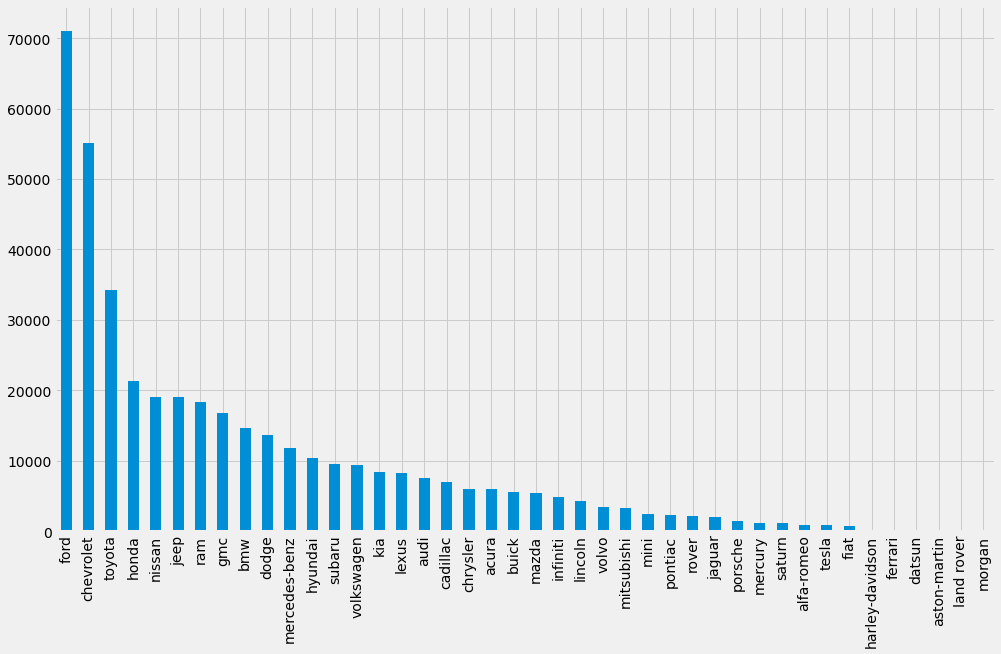

```python
df['manufacturer'].value_counts().plot(kind='bar')
```

```python
df['model'].unique()
```

```
array([nan, 'sierra 1500 crew cab slt', 'silverado 1500', ...,
       'gand wagoneer', '96 Suburban', 'Paige Glenbrook Touring'],
      dtype=object)
```

```python
df.groupby('model')['price'].describe()
```

| model | count | mean | std | min | 25% | 50% | 75% | max |
| --- | --- | --- | --- | --- | --- | --- | --- | --- |
| "t" | 1.00 | 27000.00 | NaN | 27000.00 | 27000.00 | 27000.00 | 27000.00 | 27000.00 |
| #NAME? | 41.00 | 16492.07 | 11764.10 | 0.00 | 10882.00 | 11882.00 | 21925.00 | 43795.00 |
| $362.47, $1000 down, oac, 2.9%apr $362.47,luxury low miles $1000 down, only 40k miles | 1.00 | 24900.00 | NaN | 24900.00 | 24900.00 | 24900.00 | 24900.00 | 24900.00 |
| % | 1.00 | 1000.00 | NaN | 1000.00 | 1000.00 | 1000.00 | 1000.00 | 1000.00 |
| & altima | 1.00 | 3045.00 | NaN | 3045.00 | 3045.00 | 3045.00 | 3045.00 | 3045.00 |
| ... | ... | ... | ... | ... | ... | ... | ... | ... |
| ♦ALL TADES WELCOME!♦ | 2.00 | 500.00 | 0.00 | 500.00 | 500.00 | 500.00 | 500.00 | 500.00 |
| ♿ | 1.00 | 10999.00 | NaN | 10999.00 | 10999.00 | 10999.00 | 10999.00 | 10999.00 |
| ♿ vmi | 2.00 | 10997.00 | 2.83 | 10995.00 | 10996.00 | 10997.00 | 10998.00 | 10999.00 |
| 𝓜𝓮𝓻𝓬𝓮𝓭𝓮𝓼 𝓫𝓮𝓷𝔃 𝓶𝓵 350 | 1.00 | 3900.00 | NaN | 3900.00 | 3900.00 | 3900.00 | 3900.00 | 3900.00 |
| 🔥GMC Sierra 1500 SLE🔥 4X4 🔥 | 1.00 | 9999.00 | NaN | 9999.00 | 9999.00 | 9999.00 | 9999.00 | 9999.00 |

29649 rows × 8 columns

[figure not shown]

```python
df['model'].value_counts().plot(kind='bar')
```

```python
df['transmission'].unique()
```

```
array([nan, 'other', 'automatic', 'manual'], dtype=object)
```

```python
df.groupby('transmission')['price'].describe()
```

| transmission | count | mean | std | min | 25% | 50% | 75% | max |
| --- | --- | --- | --- | --- | --- | --- | --- | --- |
| automatic | 336524.00 | 74881.00 | 13113970.10 | 0.00 | 4999.00 | 11450.00 | 22775.00 | 3736928711.00 |
| manual | 25118.00 | 198416.34 | 14747142.05 | 0.00 | 4500.00 | 9000.00 | 18995.00 | 1410065407.00 |
| other | 62682.00 | 30003.79 | 495473.78 | 0.00 | 20590.00 | 27990.00 | 34990.00 | 123456789.00 |

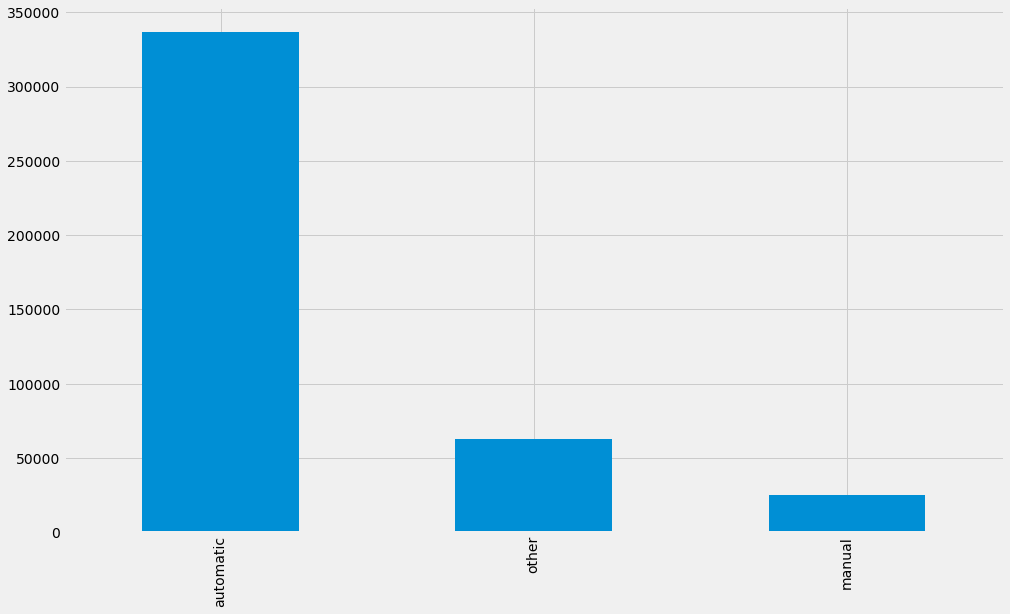

```python
df['transmission'].value_counts().plot(kind='bar')
```

```python
df['condition'].unique()
```

```
array([nan, 'good', 'excellent', 'fair', 'like new', 'new', 'salvage'],
      dtype=object)
```

```python
df.groupby('condition')['price'].describe()
```

| condition | count | mean | std | min | 25% | 50% | 75% | max |
| --- | --- | --- | --- | --- | --- | --- | --- | --- |
| excellent | 101467.00 | 51346.83 | 11731431.48 | 0.00 | 5999.50 | 10995.00 | 18990.00 | 3736928711.00 |
| fair | 6769.00 | 761090.01 | 47857081.19 | 0.00 | 1500.00 | 2800.00 | 4900.00 | 3736928711.00 |
| good | 121456.00 | 32545.20 | 3228825.93 | 0.00 | 7900.00 | 19995.00 | 30990.00 | 1111111111.00 |
| like new | 21178.00 | 36402.04 | 1516448.97 | 0.00 | 6800.00 | 13950.00 | 25000.00 | 135008900.00 |
| new | 1305.00 | 23657.27 | 26895.25 | 0.00 | 1000.00 | 15900.00 | 35114.00 | 182000.00 |
| salvage | 601.00 | 3605.53 | 4706.32 | 0.00 | 950.00 | 1800.00 | 4500.00 | 35989.00 |

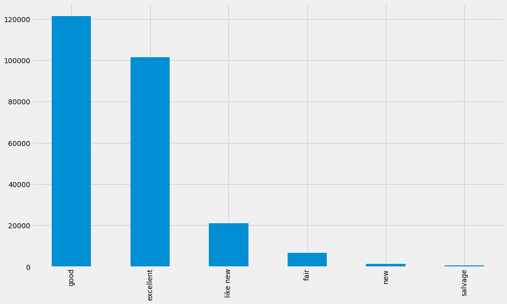

```python
df['condition'].value_counts().plot(kind='bar')
```

```python
df['drive'].unique()
```

```
array([nan, 'rwd', '4wd', 'fwd'], dtype=object)
```

```python
df.groupby('drive')['price'].describe()
```

| drive | count | mean | std | min | 25% | 50% | 75% | max |
| --- | --- | --- | --- | --- | --- | --- | --- | --- |
| 4wd | 131904.00 | 112029.80 | 17029939.68 | 0.00 | 7500.00 | 17999.00 | 32500.00 | 3736928711.00 |
| fwd | 105517.00 | 15300.88 | 658670.34 | 0.00 | 4950.00 | 9495.00 | 16950.00 | 123456789.00 |
| rwd | 58892.00 | 40795.62 | 4606672.36 | 0.00 | 7500.00 | 17500.00 | 29500.00 | 1111111111.00 |

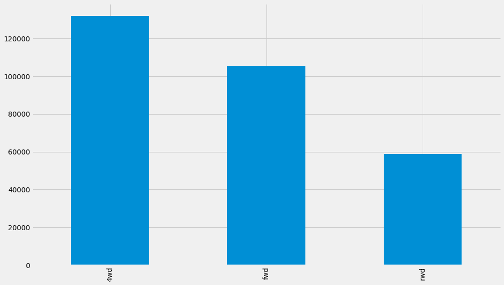

```python
df['drive'].value_counts().plot(kind='bar')
```

```python
df['state'].unique()
```

```
array(['az', 'ar', 'fl', 'ma', 'nc', 'ny', 'or', 'pa', 'tx', 'wa', 'wi',
       'al', 'ak', 'ca', 'co', 'ct', 'dc', 'de', 'ga', 'hi', 'id', 'il',
       'in', 'ia', 'ks', 'ky', 'la', 'me', 'md', 'mi', 'mn', 'ms', 'mo',
       'mt', 'ne', 'nv', 'nj', 'nm', 'nh', 'nd', 'oh', 'ok', 'ri', 'sc',
       'sd', 'tn', 'ut', 'vt', 'va', 'wv', 'wy'], dtype=object)
```

```python
df.groupby('state')['price'].describe()
```

| state | count | mean | std | min | 25% | 50% | 75% | max |
| --- | --- | --- | --- | --- | --- | --- | --- | --- |
| ak | 3474.00 | 23745.82 | 14369.38 | 0.00 | 13995.00 | 21999.00 | 30984.75 | 145000.00 |
| al | 4955.00 | 239642.53 | 14101966.66 | 0.00 | 7980.00 | 18989.00 | 29990.00 | 987654321.00 |
| ar | 4038.00 | 18061.28 | 17476.04 | 0.00 | 3999.00 | 14499.50 | 28063.00 | 163540.00 |
| az | 8679.00 | 19482.62 | 16737.58 | 0.00 | 7500.00 | 15990.00 | 27987.00 | 239995.00 |
| ca | 50614.00 | 120121.12 | 15090544.11 | 0.00 | 5500.00 | 12990.00 | 24981.00 | 3009548743.00 |
| co | 11088.00 | 18117.45 | 15800.59 | 0.00 | 6995.00 | 14999.00 | 25999.00 | 655000.00 |
| ct | 5188.00 | 15039.16 | 23107.79 | 0.00 | 5495.00 | 9995.00 | 21888.00 | 1000000.00 |
| dc | 2970.00 | 14480.13 | 14221.52 | 0.00 | 4900.00 | 10999.00 | 22491.25 | 304995.00 |
| de | 949.00 | 3205055.89 | 98193222.87 | 0.00 | 4999.00 | 9795.00 | 24990.00 | 3024942282.00 |
| fl | 28511.00 | 17852.28 | 44840.63 | 0.00 | 5995.00 | 13995.00 | 25990.00 | 6995495.00 |
| ga | 7003.00 | 159261.23 | 11801989.59 | 0.00 | 5599.00 | 16590.00 | 28893.50 | 987654321.00 |
| hi | 2964.00 | 19742.60 | 18214.95 | 0.00 | 6175.00 | 17989.00 | 28888.00 | 289995.00 |
| ia | 8632.00 | 16183.89 | 13458.15 | 0.00 | 6995.00 | 12995.00 | 22950.00 | 215000.00 |
| id | 8961.00 | 35638.50 | 1316354.44 | 0.00 | 6995.00 | 14995.00 | 29999.00 | 123456789.00 |
| il | 10387.00 | 16559.76 | 14748.27 | 0.00 | 5000.00 | 12995.00 | 25590.00 | 260995.00 |
| in | 5704.00 | 235833.07 | 16346275.97 | 0.00 | 6950.00 | 15999.50 | 29301.00 | 1234567890.00 |
| ks | 6209.00 | 18954.53 | 15293.62 | 0.00 | 6995.00 | 15947.00 | 27800.00 | 163540.00 |
| ky | 4149.00 | 19061.85 | 12526.92 | 0.00 | 8945.00 | 16900.00 | 27990.00 | 123456.00 |
| la | 3196.00 | 17929.55 | 16434.09 | 0.00 | 5595.00 | 15000.00 | 27990.00 | 299991.00 |
| ma | 8174.00 | 15582.39 | 13900.00 | 0.00 | 5495.00 | 11755.00 | 23500.00 | 139950.00 |
| md | 4778.00 | 312340.39 | 20399099.70 | 0.00 | 4496.25 | 14499.00 | 27990.00 | 1410065407.00 |
| me | 2966.00 | 13782.82 | 14701.29 | 0.00 | 3495.00 | 9995.00 | 19495.00 | 175000.00 |
| mi | 16900.00 | 30072.55 | 1342929.07 | 0.00 | 5900.00 | 10990.00 | 22950.00 | 123456789.00 |
| mn | 7716.00 | 16037.20 | 17727.67 | 0.00 | 5990.00 | 13200.00 | 23995.00 | 1111111.00 |
| mo | 4293.00 | 20872.68 | 16494.93 | 0.00 | 7995.00 | 17995.00 | 30990.00 | 299500.00 |
| ms | 1016.00 | 17609.73 | 37077.89 | 0.00 | 6150.00 | 12935.50 | 23995.00 | 1111111.00 |
| mt | 6294.00 | 23515.94 | 17120.00 | 0.00 | 9500.00 | 21995.00 | 35997.25 | 163540.00 |
| nc | 15277.00 | 32828.72 | 1426700.89 | 0.00 | 4295.00 | 13300.00 | 25999.00 | 135008900.00 |
| nd | 410.00 | 22326.35 | 82435.09 | 0.00 | 9995.00 | 15990.00 | 23990.00 | 1666666.00 |
| ne | 1036.00 | 18701.60 | 15646.07 | 0.00 | 7500.00 | 13894.00 | 26096.00 | 124900.00 |
| nh | 2981.00 | 17645.68 | 94471.94 | 0.00 | 5995.00 | 12575.00 | 22900.00 | 5000000.00 |
| nj | 9742.00 | 325456.54 | 30647208.50 | 0.00 | 5400.00 | 10772.50 | 21990.00 | 3024942282.00 |
| nm | 4425.00 | 19041.87 | 17415.63 | 0.00 | 5800.00 | 15990.00 | 28590.00 | 163540.00 |
| nv | 3194.00 | 20574.81 | 17577.26 | 0.00 | 8550.00 | 16999.00 | 27990.00 | 179888.00 |
| ny | 19386.00 | 16976.52 | 14857.59 | 0.00 | 5900.00 | 13500.00 | 25990.00 | 261895.00 |
| oh | 17696.00 | 26833.67 | 958319.69 | 0.00 | 4950.00 | 10950.00 | 22998.25 | 123456789.00 |
| ok | 6792.00 | 36207.10 | 1497949.66 | 0.00 | 4200.00 | 14774.00 | 27990.00 | 123456789.00 |
| or | 17104.00 | 234168.89 | 28573552.16 | 0.00 | 540.50 | 9995.00 | 23987.25 | 3736928711.00 |
| pa | 13753.00 | 15542.14 | 30727.53 | 0.00 | 5500.00 | 10500.00 | 23000.00 | 3226714.00 |
| ri | 2320.00 | 16424.11 | 13623.15 | 0.00 | 5995.00 | 11995.00 | 24922.50 | 129500.00 |
| sc | 6327.00 | 18823.20 | 14883.61 | 0.00 | 6690.00 | 16480.00 | 28990.00 | 117995.00 |
| sd | 1302.00 | 18369.45 | 15216.56 | 0.00 | 6412.50 | 14500.00 | 26993.25 | 125000.00 |
| tn | 11066.00 | 369348.03 | 35543039.87 | 0.00 | 8900.00 | 17500.00 | 27988.75 | 3736928711.00 |
| tx | 22945.00 | 21344.02 | 167877.51 | 0.00 | 6500.00 | 16990.00 | 29969.00 | 25003000.00 |
| ut | 1150.00 | 25099.98 | 21513.85 | 0.00 | 7950.00 | 19897.50 | 35990.00 | 160000.00 |
| va | 10732.00 | 13877.01 | 14071.50 | 0.00 | 3500.00 | 8990.00 | 21795.00 | 304995.00 |
| vt | 2513.00 | 16579.10 | 12584.84 | 0.00 | 7800.00 | 13995.00 | 22995.00 | 120000.00 |
| wa | 13861.00 | 22221.34 | 20601.88 | 0.00 | 5500.00 | 16873.00 | 34999.00 | 239900.00 |
| wi | 11398.00 | 16529.63 | 16088.60 | 0.00 | 5999.00 | 13487.00 | 24990.00 | 999999.00 |
| wv | 1052.00 | 24317.42 | 16185.85 | 0.00 | 12000.00 | 24918.00 | 33998.25 | 163540.00 |
| wy | 610.00 | 21104.07 | 15760.24 | 0.00 | 8582.75 | 18545.00 | 29999.00 | 125000.00 |

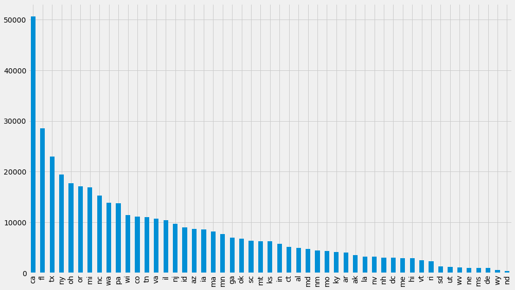

```python
df['state'].value_counts().plot(kind='bar')
```

```python
df['fuel'].unique()
```

```
array([nan, 'gas', 'other', 'diesel', 'hybrid', 'electric'], dtype=object)
```

```python
df.groupby('fuel')['price'].describe()
```

| fuel | count | mean | std | min | 25% | 50% | 75% | max |
| --- | --- | --- | --- | --- | --- | --- | --- | --- |
| diesel | 30062.00 | 118177.69 | 10378576.07 | 0.00 | 11000.00 | 27990.00 | 44900.00 | 1410065407.00 |
| electric | 1698.00 | 24648.36 | 17198.26 | 0.00 | 11590.00 | 22544.50 | 36590.00 | 130000.00 |
| gas | 356209.00 | 73902.26 | 12825069.74 | 0.00 | 5495.00 | 11998.00 | 23876.00 | 3736928711.00 |
| hybrid | 5170.00 | 14582.43 | 11479.14 | 0.00 | 6512.50 | 11995.00 | 19990.00 | 109999.00 |
| other | 30728.00 | 66811.40 | 7043045.82 | 0.00 | 16495.00 | 25990.00 | 33990.00 | 1234567890.00 |

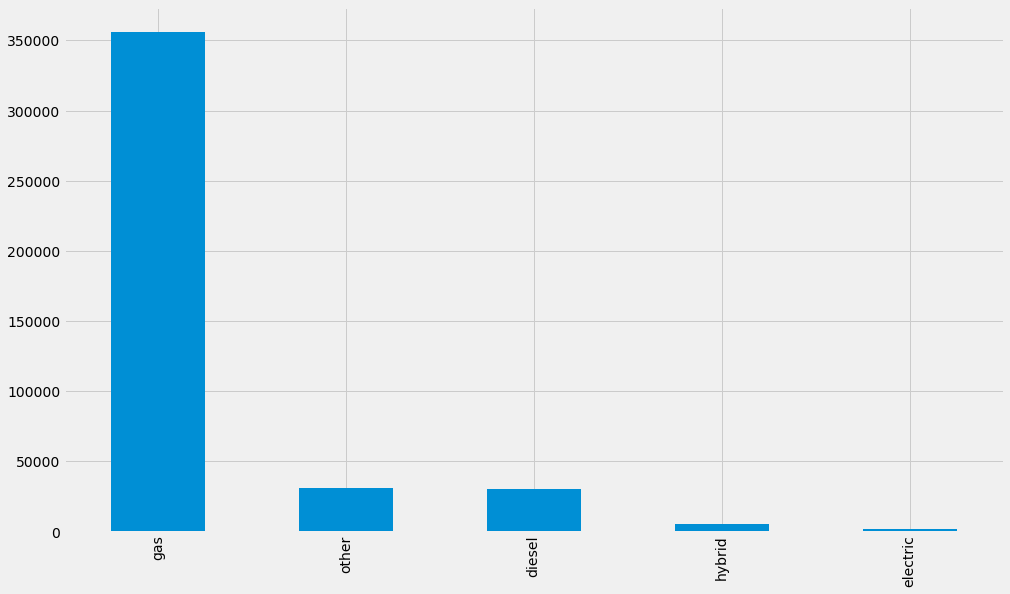

```python
df['fuel'].value_counts().plot(kind='bar')
```

```python
df['year'].unique()
```

```
array([  nan, 2014., 2010., 2020., 2017., 2013., 2012., 2016., 2019.,
       2011., 1992., 2018., 2004., 2015., 2001., 2006., 1968., 2003.,
       2008., 2007., 2005., 1966., 2009., 1998., 2002., 1999., 2021.,
       1997., 1976., 1969., 1995., 1978., 1954., 1979., 1970., 1974.,
       1996., 1987., 2000., 1955., 1960., 1991., 1972., 1988., 1994.,
       1929., 1984., 1986., 1989., 1973., 1946., 1933., 1958., 1937.,
       1985., 1957., 1953., 1942., 1963., 1977., 1993., 1903., 1990.,
       1965., 1982., 1948., 1983., 1936., 1932., 1951., 1931., 1980.,
       1967., 1971., 1947., 1981., 1926., 1962., 1975., 1964., 1934.,
       1952., 1940., 1959., 1950., 1930., 1956., 1922., 1928., 2022.,
       1901., 1941., 1924., 1927., 1939., 1923., 1949., 1961., 1935.,
       1918., 1900., 1938., 1913., 1916., 1943., 1925., 1921., 1915.,
       1945., 1902., 1905., 1920., 1944., 1910., 1909.])
```

```python
df.groupby('year')['price'].describe()
```

| year | count | mean | std | min | 25% | 50% | 75% | max |
| --- | --- | --- | --- | --- | --- | --- | --- | --- |
| 1900.00 | 12.00 | 3694.17 | 10957.78 | 1.00 | 1.00 | 1.00 | 624.50 | 38250.00 |
| 1901.00 | 3.00 | 1699.67 | 2042.23 | 100.00 | 549.50 | 999.00 | 2499.50 | 4000.00 |
| 1902.00 | 1.00 | 1666666.00 | NaN | 1666666.00 | 1666666.00 | 1666666.00 | 1666666.00 | 1666666.00 |
| 1903.00 | 12.00 | 0.00 | 0.00 | 0.00 | 0.00 | 0.00 | 0.00 | 0.00 |
| 1905.00 | 1.00 | 3990.00 | NaN | 3990.00 | 3990.00 | 3990.00 | 3990.00 | 3990.00 |
| ... | ... | ... | ... | ... | ... | ... | ... | ... |
| 2018.00 | 36369.00 | 26368.61 | 16630.85 | 0.00 | 17990.00 | 26995.00 | 35590.00 | 299500.00 |
| 2019.00 | 25375.00 | 32975.53 | 190349.38 | 0.00 | 19998.00 | 30590.00 | 38998.00 | 12345678.00 |
| 2020.00 | 19298.00 | 91897.71 | 7998143.70 | 0.00 | 23990.00 | 34990.00 | 42590.00 | 1111111111.00 |
| 2021.00 | 2396.00 | 1338055.31 | 61533516.55 | 0.00 | 295.00 | 23500.00 | 46000.00 | 3009548743.00 |
| 2022.00 | 133.00 | 27367.05 | 148621.76 | 0.00 | 1.00 | 426.00 | 2500.00 | 1000000.00 |

114 rows × 8 columns

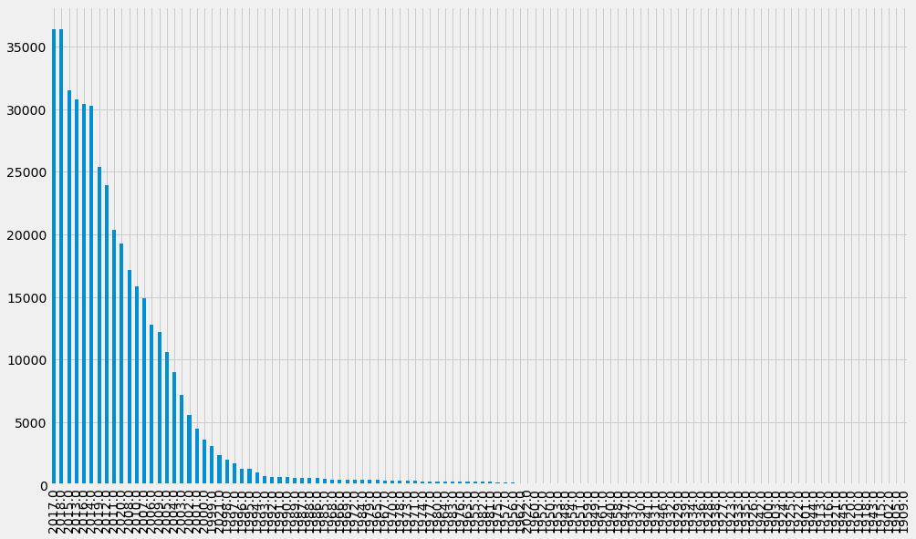

```python
df['year'].value_counts().plot(kind='bar')
```

```python
df["price_log"] = np.log(df_numeric['price'])
```

```python
df['cylinders'].unique()
```

```
array([nan, '8 cylinders', '6 cylinders', '4 cylinders', '5 cylinders',
       'other', '3 cylinders', '10 cylinders', '12 cylinders'],
      dtype=object)
```

```python
df.groupby('cylinders')['price'].describe()
```

| cylinders | count | mean | std | min | 25% | 50% | 75% | max |
| --- | --- | --- | --- | --- | --- | --- | --- | --- |
| 10 cylinders | 1455.00 | 21507.80 | 30402.25 | 0.00 | 4995.00 | 14995.00 | 28944.00 | 299991.00 |
| 12 cylinders | 209.00 | 54299.38 | 72929.80 | 0.00 | 10000.00 | 28990.00 | 65995.00 | 516999.00 |
| 3 cylinders | 655.00 | 12297.00 | 12257.64 | 0.00 | 5000.00 | 9990.00 | 17989.50 | 128995.00 |
| 4 cylinders | 77642.00 | 10545.30 | 27386.81 | 0.00 | 4750.00 | 8500.00 | 14577.50 | 6995495.00 |
| 5 cylinders | 1712.00 | 7842.78 | 11744.33 | 0.00 | 3995.00 | 6200.00 | 8999.00 | 400123.00 |
| 6 cylinders | 94169.00 | 58696.32 | 12184436.99 | 0.00 | 5500.00 | 13995.00 | 27655.00 | 3736928711.00 |
| 8 cylinders | 72062.00 | 139595.72 | 18371107.63 | 0.00 | 7900.00 | 18900.00 | 33895.00 | 3736928711.00 |
| other | 1298.00 | 17110.08 | 19435.71 | 0.00 | 2650.00 | 9991.50 | 24999.00 | 130000.00 |

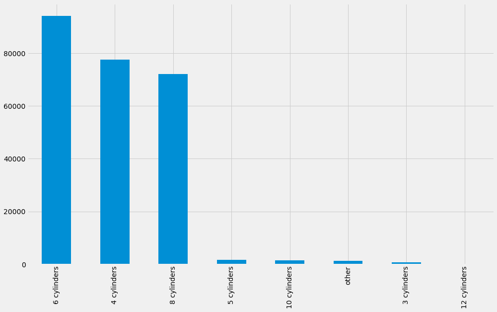

```python
df['cylinders'].value_counts().plot(kind='bar')
```

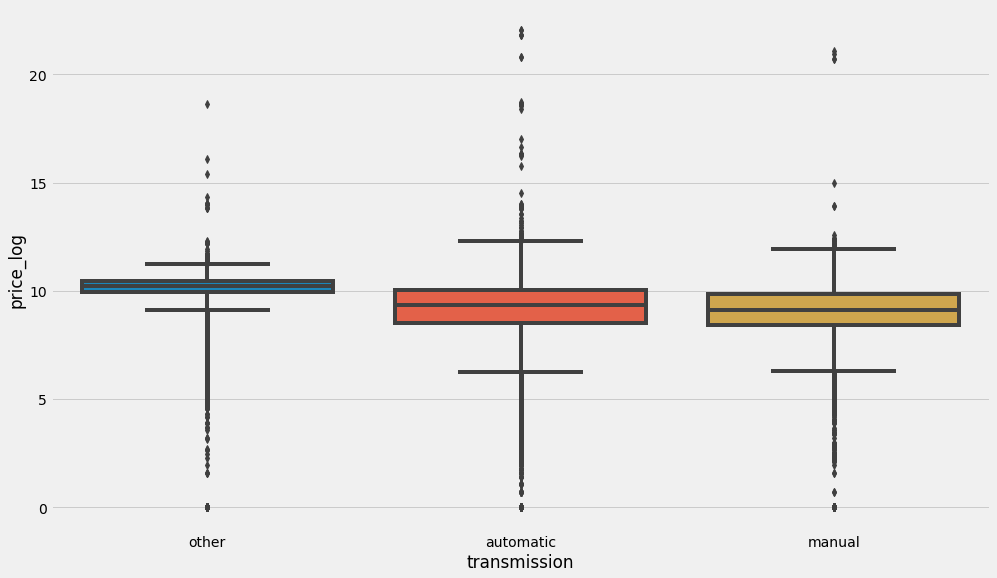

```python
#  df["price_log"] = np.log(df['price'])
sns.boxplot(x = 'transmission', y = 'price_log', data = df);
```

```python
#  df["price_log"] = np.log(df['price'])
#sns.boxplot(x = 'model', y = 'price_log', data = df);
```

## Data Pre-processing

We will build a model using only the numeric values given in the dataset.

```python
numeric_cols = ['year', 'odometer', 'price']
df[numeric_cols]
```

|  | year | odometer | price |
| --- | --- | --- | --- |
| 0 | NaN | NaN | 6000 |
| 1 | NaN | NaN | 11900 |
| 2 | NaN | NaN | 21000 |
| 3 | NaN | NaN | 1500 |
| 4 | NaN | NaN | 4900 |
| ... | ... | ... | ... |
| 426875 | 2019.00 | 32226.00 | 23590 |
| 426876 | 2020.00 | 12029.00 | 30590 |
| 426877 | 2020.00 | 4174.00 | 34990 |
| 426878 | 2018.00 | 30112.00 | 28990 |
| 426879 | 2019.00 | 22716.00 | 30590 |

426880 rows × 3 columns

```python
df.median()
```

```
id          7312620821.00
price            13950.00
year              2013.00
odometer         85548.00
price_log            9.54
dtype: float64
```

```python
df_numeric = df[numeric_cols].copy()
```

```python
df_numeric.isna().mean()
```

```
year       0.00
odometer   0.01
price      0.00
dtype: float64
```

```python
df_numeric.median()
```

```
year        2013.00
odometer   85548.00
price      13950.00
dtype: float64
```

**Fill in the missing values**

```python
df_numeric.fillna(df_numeric.median(), inplace = True)
```

**TRAIN TEST SPLIT the DATA**

```python
X = df_numeric.drop(columns = 'price')
y = df_numeric['price']
```

```python
df_numeric['price']
```

```
0          6000
1         11900
2         21000
3          1500
4          4900
          ...
426875    23590
426876    30590
426877    34990
426878    28990
426879    30590
Name: price, Length: 426880, dtype: int64
```

```python
X_train, X_test, y_train, y_test = train_test_split(X, y, test_size = 0.20, random_state = 1)
```

```python
# The split done for model creation

print(X_train.shape)
print(X_test.shape)
print(df.shape)

print("=" * 50)

print(y_train.shape)
print(y_test.shape)
```

```
(341504, 2)
(85376, 2)
(426880, 19)
==================================================
(341504,)
(85376,)
```

```python
y_train
```

```
236138    19500
244691     7500
379423     2500
194037    19990
419430    45990
          ...
73349         0
371403    15999
312201    54990
267336    35990
128037    35995
Name: price, Length: 341504, dtype: int64
```

### Modeling

With your (almost?) final dataset in hand, it is now time to build some models. Here, you should build a number of different regression models with the price as the target. In building your models, you should explore different parameters and be sure to cross-validate your findings.

### Linear Regression

```python
lr = LinearRegression()
```

```python
df_numeric.isna().sum()
```

```
year        0
odometer    0
price       0
dtype: int64
```

```python
# LINEAR REGRESSION
# fit the model
lr.fit(X_train, y_train)

# R^2 of the model
lr_r2 = (lr.score(X_train, y_train))
print("The value of lr_r2 is {:.2f}".format(lr_r2))

# Predictions on test
lr_predict = lr.predict(X_test)

# rmse
# Still not 50%, it 46%
# Still not great

lr_rmse = mean_squared_error(y_test, lr_predict, squared = False)
print("The value of lr rmse is {:.2f}".format(lr_rmse))
```

```
The value of lr_r2 is 0.00
The value of lr rmse is 15860329.50
```

```python
# CREATING THE BASELINE
# Just predicting one average value for all points
# The value of lr_r2 is 0.00 is HORRIBLE


x = list(range(0, len(y_test)))
```

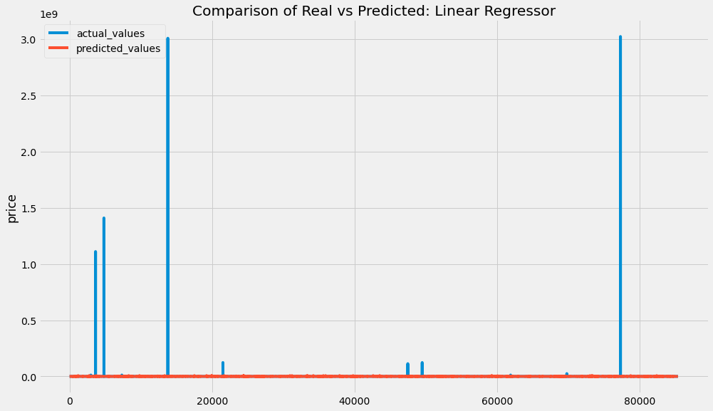

```python
sns.lineplot(x = x, y = y_test, label = "actual_values");
sns.lineplot(x = x, y = lr_predict, label = "predicted_values");

plt.title("Comparison of Real vs Predicted: Linear Regressor");
```

### Calculating Train and Test Set RMSE

**Practice other ways to improve the model**

```python
df.drop(columns = "price")
```

|  | id | region | year | manufacturer | model | condition | cylinders | fuel | odometer | title_status | transmission | VIN | drive | size | type | paint_color | state | price_log |
| --- | --- | --- | --- | --- | --- | --- | --- | --- | --- | --- | --- | --- | --- | --- | --- | --- | --- | --- |
| 0 | 7222695916 | prescott | NaN | NaN | NaN | NaN | NaN | NaN | NaN | NaN | NaN | NaN | NaN | NaN | NaN | NaN | az | 8.70 |
| 1 | 7218891961 | fayetteville | NaN | NaN | NaN | NaN | NaN | NaN | NaN | NaN | NaN | NaN | NaN | NaN | NaN | NaN | ar | 9.38 |
| 2 | 7221797935 | florida keys | NaN | NaN | NaN | NaN | NaN | NaN | NaN | NaN | NaN | NaN | NaN | NaN | NaN | NaN | fl | 9.95 |
| 3 | 7222270760 | worcester / central MA | NaN | NaN | NaN | NaN | NaN | NaN | NaN | NaN | NaN | NaN | NaN | NaN | NaN | NaN | ma | 7.31 |
| 4 | 7210384030 | greensboro | NaN | NaN | NaN | NaN | NaN | NaN | NaN | NaN | NaN | NaN | NaN | NaN | NaN | NaN | nc | 8.50 |
| ... | ... | ... | ... | ... | ... | ... | ... | ... | ... | ... | ... | ... | ... | ... | ... | ... | ... | ... |
| 426875 | 7301591192 | wyoming | 2019.00 | nissan | maxima s sedan 4d | good | 6 cylinders | gas | 32226.00 | clean | other | 1N4AA6AV6KC367801 | fwd | NaN | sedan | NaN | wy | 10.07 |
| 426876 | 7301591187 | wyoming | 2020.00 | volvo | s60 t5 momentum sedan 4d | good | NaN | gas | 12029.00 | clean | other | 7JR102FKXLG042696 | fwd | NaN | sedan | red | wy | 10.33 |
| 426877 | 7301591147 | wyoming | 2020.00 | cadillac | xt4 sport suv 4d | good | NaN | diesel | 4174.00 | clean | other | 1GYFZFR46LF088296 | NaN | NaN | hatchback | white | wy | 10.46 |
| 426878 | 7301591140 | wyoming | 2018.00 | lexus | es 350 sedan 4d | good | 6 cylinders | gas | 30112.00 | clean | other | 58ABK1GG4JU103853 | fwd | NaN | sedan | silver | wy | 10.27 |
| 426879 | 7301591129 | wyoming | 2019.00 | bmw | 4 series 430i gran coupe | good | NaN | gas | 22716.00 | clean | other | WBA4J1C58KBM14708 | rwd | NaN | coupe | NaN | wy | 10.33 |

426880 rows × 18 columns

```python
lr = LinearRegression()
```

```python
df.columns = df.columns.str.lower()
df.columns = df.columns.str.strip()
df.columns = df.columns.str.replace(" ", "_")
df[~df.duplicated()]
```

|  | id | region | price | year | manufacturer | model | condition | cylinders | fuel | odometer | title_status | transmission | vin | drive | size | type | paint_color | state | price_log |
| --- | --- | --- | --- | --- | --- | --- | --- | --- | --- | --- | --- | --- | --- | --- | --- | --- | --- | --- | --- |
| 0 | 7222695916 | prescott | 6000 | NaN | NaN | NaN | NaN | NaN | NaN | NaN | NaN | NaN | NaN | NaN | NaN | NaN | NaN | az | 8.70 |
| 1 | 7218891961 | fayetteville | 11900 | NaN | NaN | NaN | NaN | NaN | NaN | NaN | NaN | NaN | NaN | NaN | NaN | NaN | NaN | ar | 9.38 |
| 2 | 7221797935 | florida keys | 21000 | NaN | NaN | NaN | NaN | NaN | NaN | NaN | NaN | NaN | NaN | NaN | NaN | NaN | NaN | fl | 9.95 |
| 3 | 7222270760 | worcester / central MA | 1500 | NaN | NaN | NaN | NaN | NaN | NaN | NaN | NaN | NaN | NaN | NaN | NaN | NaN | NaN | ma | 7.31 |
| 4 | 7210384030 | greensboro | 4900 | NaN | NaN | NaN | NaN | NaN | NaN | NaN | NaN | NaN | NaN | NaN | NaN | NaN | NaN | nc | 8.50 |
| ... | ... | ... | ... | ... | ... | ... | ... | ... | ... | ... | ... | ... | ... | ... | ... | ... | ... | ... | ... |
| 426875 | 7301591192 | wyoming | 23590 | 2019.00 | nissan | maxima s sedan 4d | good | 6 cylinders | gas | 32226.00 | clean | other | 1N4AA6AV6KC367801 | fwd | NaN | sedan | NaN | wy | 10.07 |
| 426876 | 7301591187 | wyoming | 30590 | 2020.00 | volvo | s60 t5 momentum sedan 4d | good | NaN | gas | 12029.00 | clean | other | 7JR102FKXLG042696 | fwd | NaN | sedan | red | wy | 10.33 |
| 426877 | 7301591147 | wyoming | 34990 | 2020.00 | cadillac | xt4 sport suv 4d | good | NaN | diesel | 4174.00 | clean | other | 1GYFZFR46LF088296 | NaN | NaN | hatchback | white | wy | 10.46 |
| 426878 | 7301591140 | wyoming | 28990 | 2018.00 | lexus | es 350 sedan 4d | good | 6 cylinders | gas | 30112.00 | clean | other | 58ABK1GG4JU103853 | fwd | NaN | sedan | silver | wy | 10.27 |
| 426879 | 7301591129 | wyoming | 30590 | 2019.00 | bmw | 4 series 430i gran coupe | good | NaN | gas | 22716.00 | clean | other | WBA4J1C58KBM14708 | rwd | NaN | coupe | NaN | wy | 10.33 |

426880 rows × 19 columns

```python
df.isna().mean()
```

```
id             0.00
region         0.00
price          0.00
year           0.00
manufacturer   0.04
model          0.01
condition      0.41
cylinders      0.42
fuel           0.01
odometer       0.01
title_status   0.02
transmission   0.01
vin            0.38
drive          0.31
size           0.72
type           0.22
paint_color    0.31
state          0.00
price_log      0.00
dtype: float64
```

```python
# Fill all the missing values with median values
df.fillna(df.median(), inplace = True)
df.drop(columns=['vin', 'drive', 'size'])
```

|  | id | region | price | year | manufacturer | model | condition | cylinders | fuel | odometer | title_status | transmission | type | paint_color | state | price_log |
| --- | --- | --- | --- | --- | --- | --- | --- | --- | --- | --- | --- | --- | --- | --- | --- | --- |
| 0 | 7222695916 | prescott | 6000 | 2013.00 | NaN | NaN | NaN | NaN | NaN | 85548.00 | NaN | NaN | NaN | NaN | az | 8.70 |
| 1 | 7218891961 | fayetteville | 11900 | 2013.00 | NaN | NaN | NaN | NaN | NaN | 85548.00 | NaN | NaN | NaN | NaN | ar | 9.38 |
| 2 | 7221797935 | florida keys | 21000 | 2013.00 | NaN | NaN | NaN | NaN | NaN | 85548.00 | NaN | NaN | NaN | NaN | fl | 9.95 |
| 3 | 7222270760 | worcester / central MA | 1500 | 2013.00 | NaN | NaN | NaN | NaN | NaN | 85548.00 | NaN | NaN | NaN | NaN | ma | 7.31 |
| 4 | 7210384030 | greensboro | 4900 | 2013.00 | NaN | NaN | NaN | NaN | NaN | 85548.00 | NaN | NaN | NaN | NaN | nc | 8.50 |
| ... | ... | ... | ... | ... | ... | ... | ... | ... | ... | ... | ... | ... | ... | ... | ... | ... |
| 426875 | 7301591192 | wyoming | 23590 | 2019.00 | nissan | maxima s sedan 4d | good | 6 cylinders | gas | 32226.00 | clean | other | sedan | NaN | wy | 10.07 |
| 426876 | 7301591187 | wyoming | 30590 | 2020.00 | volvo | s60 t5 momentum sedan 4d | good | NaN | gas | 12029.00 | clean | other | sedan | red | wy | 10.33 |
| 426877 | 7301591147 | wyoming | 34990 | 2020.00 | cadillac | xt4 sport suv 4d | good | NaN | diesel | 4174.00 | clean | other | hatchback | white | wy | 10.46 |
| 426878 | 7301591140 | wyoming | 28990 | 2018.00 | lexus | es 350 sedan 4d | good | 6 cylinders | gas | 30112.00 | clean | other | sedan | silver | wy | 10.27 |
| 426879 | 7301591129 | wyoming | 30590 | 2019.00 | bmw | 4 series 430i gran coupe | good | NaN | gas | 22716.00 | clean | other | coupe | NaN | wy | 10.33 |

426880 rows × 16 columns

```python
df.isna().sum()
```

```
id                   0
region               0
price                0
year                 0
manufacturer     17646
model             5277
condition       174104
cylinders       177678
fuel              3013
odometer             0
title_status      8242
transmission      2556
vin             161042
drive           130567
size            306361
type             92858
paint_color     130203
state                0
price_log            0
dtype: int64
```

```python
df.columns
```

```
Index(['id', 'region', 'price', 'year', 'manufacturer', 'model', 'condition',
       'cylinders', 'fuel', 'odometer', 'title_status', 'transmission', 'vin',
       'drive', 'size', 'type', 'paint_color', 'state', 'price_log'],
      dtype='object')
```

```python
#df = pd.read_csv("data/vehicles.csv",  chunksize=1000,  sep=',')

# Putting the tokenizer into action
# https://stackoverflow.com/questions/55188544/pandas-how-to-workaround-error-tokenizing-data
```

```python
# Too much memory was being used so the datafranme is reduced
df = df.take(np.random.permutation(len(df))[:5000])
```

```python
# HOT ENCODE to convert to numeric
df_extend = pd.get_dummies(df)
```

```python
df.shape
```

```
(5000, 19)
```

```python
df_extend.head()
```

|  | id | price | year | odometer | price_log | region_SF bay area | region_abilene | region_akron / canton | region_albany | region_albuquerque | ... | state_sd | state_tn | state_tx | state_ut | state_va | state_vt | state_wa | state_wi | state_wv | state_wy |
| --- | --- | --- | --- | --- | --- | --- | --- | --- | --- | --- | --- | --- | --- | --- | --- | --- | --- | --- | --- | --- | --- |
| 212515 | 7311900677 | 12995 | 2017.00 | 104405.00 | 9.47 | 0 | 0 | 0 | 0 | 0 | ... | 0 | 0 | 0 | 0 | 0 | 0 | 0 | 0 | 0 | 0 |
| 348316 | 7307339622 | 5900 | 2006.00 | 177469.00 | 8.68 | 0 | 0 | 0 | 0 | 0 | ... | 0 | 0 | 0 | 0 | 0 | 0 | 0 | 0 | 0 | 0 |
| 109965 | 7309007691 | 19995 | 2001.00 | 104000.00 | 9.90 | 0 | 0 | 0 | 0 | 0 | ... | 0 | 0 | 0 | 0 | 0 | 0 | 0 | 0 | 0 | 0 |
| 346181 | 7304443340 | 17950 | 2013.00 | 159500.00 | 9.80 | 0 | 0 | 0 | 0 | 0 | ... | 0 | 0 | 0 | 0 | 0 | 0 | 0 | 0 | 0 | 0 |
| 283308 | 7316161580 | 27900 | 2016.00 | 49759.00 | 10.24 | 0 | 0 | 0 | 0 | 0 | ... | 0 | 0 | 0 | 0 | 0 | 0 | 0 | 0 | 0 | 0 |

5 rows × 5683 columns

```python
# Dummies create 1000 columns
# focus on low cardinality
# Focus on string list

df.select_dtypes("object").describe()
```

|  | region | manufacturer | model | condition | cylinders | fuel | title_status | transmission | vin | drive | size | type | paint_color | state |
| --- | --- | --- | --- | --- | --- | --- | --- | --- | --- | --- | --- | --- | --- | --- |
| count | 5000 | 4791 | 4940 | 2946 | 2937 | 4966 | 4898 | 4962 | 3193 | 3456 | 1374 | 3900 | 3468 | 5000 |
| unique | 371 | 39 | 2150 | 6 | 8 | 5 | 6 | 3 | 3007 | 3 | 4 | 13 | 12 | 51 |
| top | columbus | ford | f-150 | good | 6 cylinders | gas | clean | automatic | 1FTMF1CP3GKD62143 | 4wd | full-size | sedan | white | ca |
| freq | 53 | 802 | 89 | 1400 | 1145 | 4175 | 4746 | 3889 | 7 | 1530 | 719 | 1058 | 931 | 598 |

```python
string_cols = ['transmission','model','odometer', 'condition', 'manufacturer']
```

```python
numeric_cols = ['price', 'odometer', 'year']
```

```python
# REMOVE OUTLIERS
Q1 = df.quantile(0.25)
Q3 = df.quantile(0.75)
IQR = Q3 - Q1

df = df[~((df < (Q1 - 1.5 * IQR)) |(df > (Q3 + 1.5 * IQR))).any(axis=1)]
```

```python
final_list = string_cols + numeric_cols
final_list
```

```
['transmission',
 'model',
 'odometer',
 'condition',
 'manufacturer',
 'price',
 'odometer',
 'year']
```

```python
df_all = df[final_list].copy()
```

```python
df['transmission'].value_counts(normalize = True)
```

```
automatic   0.78
other       0.17
manual      0.05
Name: transmission, dtype: float64
```

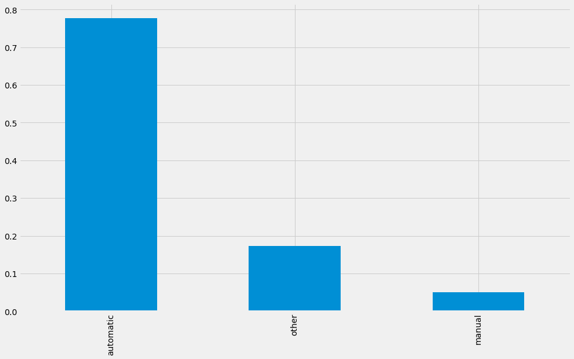

```python
df['transmission'].value_counts(normalize = True).plot(kind='bar')
```

```python
pd.get_dummies(df['transmission'])
```

|  | automatic | manual | other |
| --- | --- | --- | --- |
| 212515 | 1 | 0 | 0 |
| 348316 | 1 | 0 | 0 |
| 109965 | 1 | 0 | 0 |
| 346181 | 1 | 0 | 0 |
| 283308 | 1 | 0 | 0 |
| ... | ... | ... | ... |
| 313065 | 1 | 0 | 0 |
| 27940 | 0 | 0 | 1 |
| 97798 | 0 | 0 | 1 |
| 194257 | 1 | 0 | 0 |
| 175231 | 0 | 0 | 1 |

4148 rows × 3 columns

```python
pd.get_dummies(df['transmission']).shape
```

```
(4148, 3)
```

```python
# To reduce the noise as best practice, you drop this. This is used a lot.

pd.get_dummies(df['transmission'], drop_first=True)
```

|  | manual | other |
| --- | --- | --- |
| 212515 | 0 | 0 |
| 348316 | 0 | 0 |
| 109965 | 0 | 0 |
| 346181 | 0 | 0 |
| 283308 | 0 | 0 |
| ... | ... | ... |
| 313065 | 0 | 0 |
| 27940 | 0 | 1 |
| 97798 | 0 | 1 |
| 194257 | 0 | 0 |
| 175231 | 0 | 1 |

4148 rows × 2 columns

```python
df_all_dummied = pd.get_dummies(df_all, drop_first = True)
```

```python
pd.get_dummies(df['transmission'], drop_first = True).shape
```

```
(4148, 2)
```

```python
# Fill in the median values at NA
df_all_dummied = df_all_dummied.fillna(df_all_dummied.median())
```

```python
# BUILD THE MODEL
# DO THE SPLIT
X = df_all_dummied.drop(columns = 'price')
y = df_all_dummied['price']
```

```python
X_train, X_test, y_train, y_test = train_test_split(X, y, test_size = 0.20, random_state = 1)
```

```python
X_train.shape
```

```
(3318, 1871)
```

```python
lr = LinearRegression()
```

```python
df_all_dummied.isnull().any()
```

```
odometer                   False
price                      False
odometer                   False
year                       False
transmission_manual        False
                           ...
manufacturer_subaru        False
manufacturer_tesla         False
manufacturer_toyota        False
manufacturer_volkswagen    False
manufacturer_volvo         False
Length: 1872, dtype: bool
```

```python
#***LINEAR REGRESSION
# fit the model
lr.fit(X_train, y_train)

# R^2 of the model
lr_r2_dummy = (lr.score(X_train, y_train))
print("The value of lr_r2 is {:.2f}".format(lr_r2_dummy))

# Predictions on test
lr_predict_dummy = lr.predict(X_test)

# rmse
# Still not 50%, it 46%
# Still not great

lr_rmse_dummy = mean_squared_error(y_test, lr_predict_dummy, squared = False)
print("The value of lr rmse is {:.2f}".format(lr_rmse_dummy))


# We have crossed 50% of the time. It is not much, but you have improved
#
# R Squared improved with greater than 0.90 with MAKE added on!!!!
```

```
The value of lr_r2 is 0.91
The value of lr rmse is 8292.90
```

```python
# AWESOME! WE CAN USE THIS! 90% is great!
```

**Feature importance**

```python
feat_importances = pd.Series(lr.feature_names_in_)
feat_importances.head(50)
```

```
0                                              odometer
1                                              odometer
2                                                  year
3                                   transmission_manual
4                                    transmission_other
5                                   model_1 series 128i
6                          model_1 series 128i coupe 2d
7                    model_1 series 135i convertible 2d
8                          model_1 series 135i coupe 2d
9                             model_1.8t convertible 2d
10                            model_124 spider classica
11                                           model_128i
12                                           model_1500
13                 model_1500 4wd quad cab 140.5" sport
14                                       model_1500 4x4
```

[output cut: 36 more lines]

```python
#Correlation on the final features

#sns.heatmap(df_all_dummied, annot=True)
#plt.show()
```

**Plot Training and Test Results**

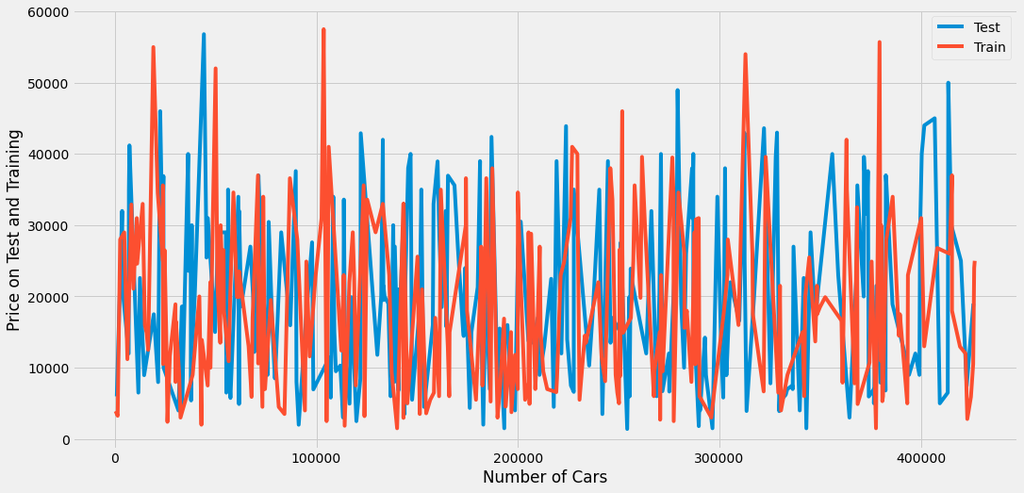

```python
plt.figure(figsize=(16,8))


#lr_rmse_dummy.sort_index().plot(kind = 'line', backend = 'plotly')
from plotly.subplots import make_subplots
import plotly.graph_objects as go


y_test.sort_index().plot(kind = 'line', backend = 'matplotlib', label='Test')
y_train.sort_index().plot(kind = 'line', backend='matplotlib', label = 'Train')

plt.ylabel('Price on Test and Training')
plt.xlabel('Number of Cars')
plt.legend()
plt.show()
```

```python
#lr_predict_dummy = lr.predict(X_test)
#df_all_dummied["price_log"] = np.log(df_all_dummied['price'])

# Replace infinite updated data with nan
#df_all_dummied.replace([np.inf, -np.inf], np.nan, inplace=True)
#df_all_dummied['price_log'].plot(kind = 'hist', bins = 40, title = "Histogram plot of price");
#df_all_dummied['price'].plot(kind = 'hist', bins = 40, title = "Histogram plot of price");
```

```python
#df_all_dummied.corr()
```

## Cross Validation

```
The Complexity that minimized Test Error was: 1
```

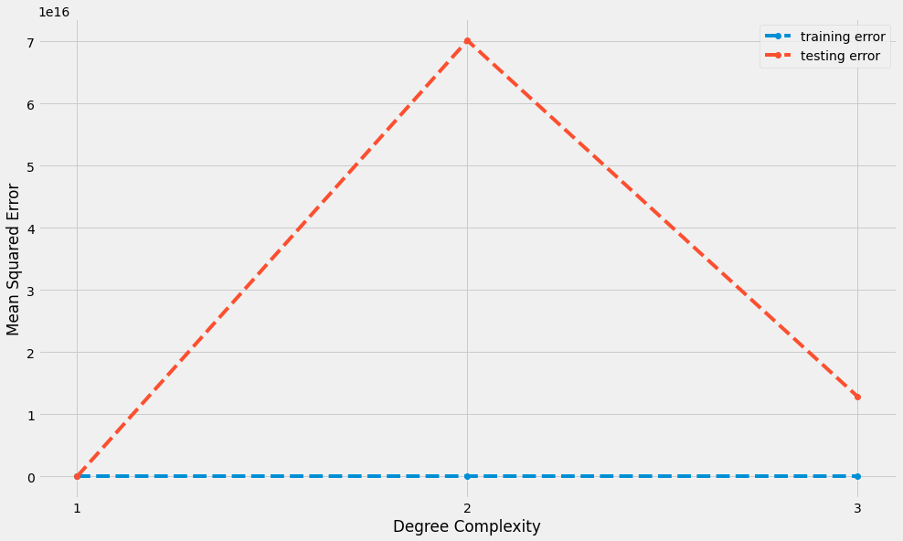

```python
from sklearn.model_selection import cross_val_score
from sklearn.model_selection import RepeatedKFold
from sklearn.linear_model import Lasso
from sklearn.model_selection import GridSearchCV

from sklearn.pipeline import Pipeline
from sklearn.preprocessing import PolynomialFeatures, OneHotEncoder, OrdinalEncoder
from sklearn.metrics import mean_squared_error
from sklearn.compose import make_column_transformer, make_column_selector

#CROSS VALDATION

# Too much memory was being used so the datafranme is reduced
df = df.take(np.random.permutation(len(df))[:500])

# REMOVE OUTLIERS
Q1 = df.quantile(0.25)
Q3 = df.quantile(0.75)
IQR = Q3 - Q1

df = df[~((df < (Q1 - 1.5 * IQR)) |(df > (Q3 + 1.5 * IQR))).any(axis=1)]


string_cols = ['transmission','model','odometer', 'condition', 'manufacturer']
numeric_cols = ['price', 'odometer', 'year']

final_list = string_cols + numeric_cols
final_list

df_all = df[final_list].copy()

df_all_dummied = pd.get_dummies(df_all, drop_first = True)

# Fill in the median values at NA
df_all_dummied = df_all_dummied.fillna(df_all_dummied.median())

# DO THE SPLIT
X = df_all_dummied.drop(columns = 'price')
y = df_all_dummied['price']

X_train, X_test, y_train, y_test = train_test_split(X, y, test_size = 0.5, random_state = 66)

############################################################################
train_mses = []
test_mses = []
for i in range(1, 4):
    pipe = Pipeline([('pfeat', PolynomialFeatures(degree = i, include_bias=False)),
                    ('linreg', LinearRegression())])
    pipe.fit(X_train, y_train)
    train_preds = pipe.predict(X_train)
    test_preds = pipe.predict(X_test)
    train_mses.append(mean_squared_error(y_train, train_preds))
    test_mses.append(mean_squared_error(y_test, test_preds))

best_model_complexity = test_mses.index(min(test_mses)) + 1

print(f'The Complexity that minimized Test Error was: {test_mses.index(min(test_mses)) + 1}')
plt.plot(range(1, 4), train_mses, '--o', label = 'training error')
plt.plot(range(1, 4), test_mses, '--o', label = 'testing error')
plt.xticks(range(1, 4), range(1, 4))
plt.xlabel('Degree Complexity')
plt.ylabel('Mean Squared Error')
plt.legend();
```

```python
def simple_cross_validation(X_train, y_train, X_test, y_test):
    best_pipe = None #placeholder for best model
    best_mse = np.inf #set best mse to infinity to begin
    for i in range(1, 4):
        pipe = Pipeline([('pfeat', PolynomialFeatures(degree = i, include_bias=False)),
                    ('linreg', LinearRegression())])
        pipe.fit(X_train, y_train)
        test_preds = pipe.predict(X_test)
        test_mse = mean_squared_error(y_test, test_preds)
        if test_mse < best_mse:
            best_mse = test_mse
            best_pipe = pipe
    return best_pipe


best_model = simple_cross_validation(X_train, y_train, X_test, y_test)
best_model.get_params() # Should give you the degree power of the polynomial
```

```
{'memory': None,
 'steps': [('pfeat', PolynomialFeatures(degree=1, include_bias=False)),
  ('linreg', LinearRegression())],
 'verbose': False,
 'pfeat': PolynomialFeatures(degree=1, include_bias=False),
 'linreg': LinearRegression(),
 'pfeat__degree': 1,
 'pfeat__include_bias': False,
 'pfeat__interaction_only': False,
 'pfeat__order': 'C',
 'linreg__copy_X': True,
 'linreg__fit_intercept': True,
 'linreg__n_jobs': None,
 'linreg__normalize': 'deprecated',
 'linreg__positive': False}
```

## Using Lasso Regression

```python
import pandas as pd
import numpy as np
from scipy import stats


import matplotlib.pyplot as plt
import seaborn as sns
plt.rcParams["figure.figsize"] = (15,9)
plt.style.use("fivethirtyeight")

# prepare data
from sklearn.model_selection import train_test_split

# model
from sklearn.dummy import DummyRegressor
from sklearn.linear_model import LinearRegression
from sklearn.metrics import mean_squared_error
from sklearn.linear_model import Lasso
from sklearn import metrics

import warnings
warnings.filterwarnings("ignore")

df = pd.read_csv("data/vehicles.csv")


plt.rcParams["figure.figsize"] = (15,9)
plt.style.use("fivethirtyeight")

# prepare data
from sklearn.model_selection import train_test_split

# model
from sklearn.dummy import DummyRegressor
from sklearn.linear_model import LinearRegression

from sklearn.metrics import mean_squared_error

import warnings
warnings.filterwarnings("ignore")

df = pd.read_csv("data/vehicles.csv")


# Too much memory was being used so the datafranme is reduced
df = df.take(np.random.permutation(len(df))[:5000])

# REMOVE OUTLIERS
Q1 = df.quantile(0.25)
Q3 = df.quantile(0.75)
IQR = Q3 - Q1

df = df[~((df < (Q1 - 1.5 * IQR)) |(df > (Q3 + 1.5 * IQR))).any(axis=1)]

# Limit the size for quicker Python run
df = df.take(np.random.permutation(len(df))[:1000])

string_cols = ['transmission','model','odometer', 'condition', 'manufacturer']
numeric_cols = ['price', 'odometer', 'year']

final_list = string_cols + numeric_cols
final_list

df_all = df[final_list].copy()

df_all_dummied = pd.get_dummies(df_all, drop_first = True)

# Fill in the median values at NA
df_all_dummied = df_all_dummied.fillna(df_all_dummied.median())

# DO THE SPLIT
X = df_all_dummied.drop(columns = 'price')
y = df_all_dummied['price']

alphas = np.logspace(-4, -0.5, 10)

tuned_parameters = [{"alpha": alphas}]
n_folds = 5

##############################################################################################

X_train, X_test, y_train, y_test = train_test_split(X, y, test_size = 0.3, random_state = 66)
lasso = Lasso()
lasso.fit(X_train, y_train)

#model = GridSearchCV(lasso, tuned_parameters, cv=n_folds, refit=False)
#model.fit(X_train, y_train)
#scores = clf.cv_results_["mean_test_score"]
#scores_std = clf.cv_results_["std_test_score"]
print("Lasso Train RMSE:", np.round(np.sqrt(metrics.mean_squared_error(y_train, lasso.predict(X_train))), 5))
print("Lasso Test RMSE:", np.round(np.sqrt(metrics.mean_squared_error(y_test, lasso.predict(X_test))), 5))
```

```
Lasso Train RMSE: 4710.59506
Lasso Test RMSE: 9850.34343
```

## Using Ridge Regression

```python
import pandas as pd
import numpy as np
from scipy import stats


import matplotlib.pyplot as plt
import seaborn as sns
plt.rcParams["figure.figsize"] = (15,9)
plt.style.use("fivethirtyeight")

# prepare data
from sklearn.model_selection import train_test_split

# model
from sklearn.dummy import DummyRegressor
from sklearn.linear_model import LinearRegression
from sklearn.metrics import mean_squared_error
from sklearn.linear_model import Lasso
from sklearn.linear_model import Ridge
from sklearn import metrics

import warnings
warnings.filterwarnings("ignore")

df = pd.read_csv("data/vehicles.csv")


plt.rcParams["figure.figsize"] = (15,9)
plt.style.use("fivethirtyeight")


# Too much memory was being used so the datafranme is reduced
df = df.take(np.random.permutation(len(df))[:5000])

# REMOVE OUTLIERS
Q1 = df.quantile(0.25)
Q3 = df.quantile(0.75)
IQR = Q3 - Q1

df = df[~((df < (Q1 - 1.5 * IQR)) |(df > (Q3 + 1.5 * IQR))).any(axis=1)]


string_cols = ['transmission','model','odometer', 'condition', 'manufacturer']
numeric_cols = ['price', 'odometer', 'year']

final_list = string_cols + numeric_cols
final_list

df_all = df[final_list].copy()

df_all_dummied = pd.get_dummies(df_all, drop_first = True)

# Fill in the median values at NA
df_all_dummied = df_all_dummied.fillna(df_all_dummied.median())

# DO THE SPLIT
X = df_all_dummied.drop(columns = 'price')
y = df_all_dummied['price']

alphas = np.logspace(-4, -0.5, 10)

tuned_parameters = [{"alpha": alphas}]
n_folds = 5

##############################################################################################

X_train, X_test, y_train, y_test = train_test_split(X, y, test_size = 0.3, random_state = 66)

# Building a Ridge Regression Model

ridge = Ridge()

# Fitting model with x and y train sets

ridge.fit(X_train, y_train)

# Calculate Ridge Train and Test Set RMSE

print("Ridge Train RMSE:", np.round(np.sqrt(metrics.mean_squared_error(y_train, ridge.predict(X_train))), 5))
print("Ridge Test RMSE:", np.round(np.sqrt(metrics.mean_squared_error(y_test, ridge.predict(X_test))), 5))

feat_importances = pd.Series(ridge.feature_names_in_)
feat_importances.head(50)
```

```
Ridge Train RMSE: 6959.41147
Ridge Test RMSE: 9657.52426
```

```
0                                   odometer
1                                   odometer
2                                       year
3                        transmission_manual
4                         transmission_other
5                                    model_-
6               model_1 series 128i coupe 2d
7         model_1 series 135i convertible 2d
8               model_1 series 135i coupe 2d
9                               model_123357
10                                model_128i
11                                model_1500
12         model_1500 2wd crew cab lone star
13         model_1500 4wd crew cab 140.5 exp
14    model_1500 4wd crew cab 140.5" laramie
```

[output cut: 36 more lines]

## Using Lasso with GridsearchCV

```python
#Using Lassso and GridSearchCV
import pandas as pd
import numpy as np
from scipy import stats


import matplotlib.pyplot as plt
import seaborn as sns
plt.rcParams["figure.figsize"] = (15,9)
plt.style.use("fivethirtyeight")

# prepare data
from sklearn.model_selection import train_test_split

# model
from sklearn.dummy import DummyRegressor
from sklearn.linear_model import LinearRegression
from sklearn.metrics import mean_squared_error
from sklearn.linear_model import Lasso
from sklearn.linear_model import Ridge
from sklearn.model_selection import GridSearchCV
from sklearn import metrics

import warnings
warnings.filterwarnings("ignore")

df = pd.read_csv("data/vehicles.csv")


plt.rcParams["figure.figsize"] = (15,9)
plt.style.use("fivethirtyeight")


# Too much memory was being used so the datafranme is reduced
df = df.take(np.random.permutation(len(df))[:5000])

# REMOVE OUTLIERS
Q1 = df.quantile(0.25)
Q3 = df.quantile(0.75)
IQR = Q3 - Q1

df = df[~((df < (Q1 - 1.5 * IQR)) |(df > (Q3 + 1.5 * IQR))).any(axis=1)]


string_cols = ['transmission','model','odometer', 'condition', 'manufacturer']
numeric_cols = ['price', 'odometer', 'year']

final_list = string_cols + numeric_cols
final_list

df_all = df[final_list].copy()

df_all_dummied = pd.get_dummies(df_all, drop_first = True)

# Fill in the median values at NA
df_all_dummied = df_all_dummied.fillna(df_all_dummied.median())

# DO THE SPLIT
X = df_all_dummied.drop(columns = 'price')
y = df_all_dummied['price']

alphas = np.logspace(-4, -0.5, 10)

tuned_parameters = [{"alpha": alphas}]
n_folds = 5

##############################################################################################

X_train, X_test, y_train, y_test = train_test_split(X, y, test_size = 0.3, random_state = 66)
lasso = Lasso()
lasso.fit(X_train, y_train)

model = GridSearchCV(lasso, tuned_parameters, cv=5, refit=True)
model.fit(X_train, y_train)
#scores = clf.cv_results_["mean_test_score"]
#scores_std = clf.cv_results_["std_test_score"]
print("Lasso Train with GridsearchCV RMSE:", np.round(np.sqrt(metrics.mean_squared_error(y_train, lasso.predict(X_train))), 5))
print("Lasso Test GridsearchCV RMSE:", np.round(np.sqrt(metrics.mean_squared_error(y_test, lasso.predict(X_test))), 5))
```

```
Lasso Train with GridsearchCV RMSE: 6545.95885
Lasso Test GridsearchCV RMSE: 10077.6384
```

## Using KFOLD

```python
#Using Lassso and GridSearchCV
import pandas as pd
import numpy as np
from scipy import stats


import matplotlib.pyplot as plt
import seaborn as sns
plt.rcParams["figure.figsize"] = (15,9)
plt.style.use("fivethirtyeight")

# prepare data
from sklearn.model_selection import train_test_split

# model
from sklearn.dummy import DummyRegressor
from sklearn.linear_model import LinearRegression
from sklearn.metrics import mean_squared_error
from sklearn.linear_model import Lasso
from sklearn.linear_model import Ridge
from sklearn.model_selection import GridSearchCV
from sklearn.model_selection import KFold
from sklearn.model_selection import cross_val_score
from sklearn import metrics
from numpy import mean
from numpy import absolute
from numpy import sqrt

import warnings
warnings.filterwarnings("ignore")

df = pd.read_csv("data/vehicles.csv")


plt.rcParams["figure.figsize"] = (15,9)
plt.style.use("fivethirtyeight")


# Too much memory was being used so the datafranme is reduced
df = df.take(np.random.permutation(len(df))[:5000])

# REMOVE OUTLIERS TO IMPROVE MODEL
Q1 = df.quantile(0.25)
Q3 = df.quantile(0.75)
IQR = Q3 - Q1

df = df[~((df < (Q1 - 1.5 * IQR)) |(df > (Q3 + 1.5 * IQR))).any(axis=1)]

# LIMIT the CATGORIES
string_cols = ['transmission','model','odometer', 'condition', 'manufacturer']
numeric_cols = ['price', 'odometer', 'year']

final_list = string_cols + numeric_cols
final_list

df_all = df[final_list].copy()

df_all_dummied = pd.get_dummies(df_all, drop_first = True)

# Fill in the median values at NA
df_all_dummied = df_all_dummied.fillna(df_all_dummied.median())

# DO THE SPLIT
X = df_all_dummied.drop(columns = 'price')
y = df_all_dummied['price']

alphas = np.logspace(-4, -0.5, 10)

tuned_parameters = [{"alpha": alphas}]
n_folds = 5

#############################################################################################


# X_train, X_test, y_train, y_test = train_test_split(X, y, test_size = 0.3, random_state = 66)

# Define the cross-validation metod to use
cv = KFold(n_splits=10,random_state=1,shuffle=True)

# Build multiple linear regression model
model = LinearRegression()

#use k-fold CV to evaluate model
scores = cross_val_score(model, X, y, scoring='neg_mean_absolute_error', cv=cv, n_jobs=-1)

print("K-Fold RMSE:")
sqrt(mean(absolute(scores)))
```

```
K-Fold RMSE:
```

```
28142.59143249232
```

```python
# HEATMAP CORRELATION
#corr = df_all_dummied.corr()
#sns.heatmap(corr, annot = True);
```

## Random Forest Algorithm

```python
#Using Linear Regression
import pandas as pd
import numpy as np
from scipy import stats


import matplotlib.pyplot as plt
import seaborn as sns
plt.rcParams["figure.figsize"] = (15,9)
plt.style.use("fivethirtyeight")

# prepare data
from sklearn.model_selection import train_test_split

# model
from sklearn.dummy import DummyRegressor
from sklearn.linear_model import LinearRegression
from sklearn.metrics import mean_squared_error
from sklearn.linear_model import Lasso
from sklearn.linear_model import Ridge
from sklearn.model_selection import GridSearchCV
from sklearn.model_selection import KFold
from sklearn.model_selection import cross_val_score
from sklearn import metrics
from numpy import mean
from numpy import absolute
from numpy import sqrt

import warnings
warnings.filterwarnings("ignore")

df = pd.read_csv("data/vehicles.csv")


plt.rcParams["figure.figsize"] = (15,9)
plt.style.use("fivethirtyeight")


# Too much memory was being used so the datafranme is reduced
df = df.take(np.random.permutation(len(df))[:5000])

# REMOVE OUTLIERS TO IMPROVE MODEL
Q1 = df.quantile(0.25)
Q3 = df.quantile(0.75)
IQR = Q3 - Q1

df = df[~((df < (Q1 - 1.5 * IQR)) |(df > (Q3 + 1.5 * IQR))).any(axis=1)]

# LIMIT the CATGORIES
string_cols = ['transmission','model','odometer', 'condition', 'manufacturer']
numeric_cols = ['price', 'odometer', 'year']

final_list = string_cols + numeric_cols
final_list

df_all = df[final_list].copy()

df_all_dummied = pd.get_dummies(df_all, drop_first = True)

# Fill in the median values at NA
df_all_dummied = df_all_dummied.fillna(df_all_dummied.median())

# DO THE SPLIT
X = df_all_dummied.drop(columns = 'price')
y = df_all_dummied['price']

alphas = np.logspace(-4, -0.5, 10)

tuned_parameters = [{"alpha": alphas}]
n_folds = 5


################################################################
# RFE with n features
from sklearn.feature_selection import RFE
from sklearn.svm import SVR
from sklearn import linear_model

classifiers = dict(
    ols=linear_model.LinearRegression(), ridge=linear_model.Ridge(alpha=0.1)
)

X_train, X_test, y_train, y_test = train_test_split(X, y, test_size = 0.3, random_state = 66)

#Import Random Forest Model
from sklearn.ensemble import RandomForestClassifier

#Create a Gaussian Classifier
clf=RandomForestClassifier(n_estimators=100)

#Train the model using the training sets y_pred=clf.predict(X_test)
clf.fit(X_train,y_train)

y_pred=clf.predict(X_test)
```

[output not shown]

```python
print("Random Forest RMSE:", np.round(np.sqrt(metrics.mean_squared_error(y_train, clf.predict(X_train))), 5))
print("Random Forest RMSE:", np.round(np.sqrt(metrics.mean_squared_error(y_test, clf.predict(X_test))), 5))
```

```
Random Forest RMSE: 7.00033
Random Forest RMSE: 13383.89169
```

### Evaluation

With some modeling accomplished, we aim to reflect on what we identify as a high quality model and what we are able to learn from this. We should review our business objective and explore how well we can provide meaningful insight on drivers of used car prices. Your goal now is to distill your findings and determine whether the earlier phases need revisitation and adjustment or if you have information of value to bring back to your client.

The categorical features which influenced the behavior were the following: 'transmission','model','odometer', 'condition', and 'manufacturer'.

The price, odometer, and year with numeric values had a large influnce in the model.

The r square was above 90% with the simple linear regression which means the feature given can be used to check further for the price prediction.

More analysis can be made using the model created, but with caution.

### Deployment

Now that we've settled on our models and findings, it is time to deliver the information to the client. You should organize your work as a basic report that details your primary findings. Keep in mind that your audience is a group of used car dealers interested in fine tuning their inventory.

The report will show the graphs without the code. Plot explanations will be given that will describe what we are trying

to achive. The model training will be used continuosly, but also new data will be needed to prefect the prediction analysis,

and the prediction error of what was expected and not received.